# Snowflake ML: Coupon Redemption Causal Analysis

Discount marketing and coupon usage are very widely used promotional techniques to attract new customers and to retain & reinforce loyalty of existing customers. The measurement of a consumer’s propensity towards coupon usage and the prediction of the redemption behaviour are crucial parameters in assessing the effectiveness of a marketing campaign.

ABC promotions are shared across various channels including email, notifications, etc. A number of these campaigns include coupon discounts that are offered for a specific product/range of products. The retailer would like the ability to predict whether customers redeem the coupons received across channels, which will enable the retailer’s marketing team to accurately design coupon construct, and develop more precise and targeted marketing strategies.

## ABOUT DATASET

1. User Demographic Details
2. Campaign and coupon Details
3. Product details
4. Previous transactions details

**LINK:** https://www.kaggle.com/datasets/vasudeva009/predicting-coupon-redemption

## OBJECTIVE

Estimate the outcome based on Redemption Status of coupons and analyse the impact of Causal Inference.

## ER Diagram

[figure not shown]

```
Steps:
1. Data Understanding and Dataset Preparation
2. Data Quality Check and Univariate/Bivariate Analysis
    a. Trend Analysis
3. Causal Analysis on
    a. Campaign Type X
    b. New Segments
```

```python
from IPython.display import display, HTML, Image , Markdown
from snowflake.snowpark.session import Session
import snowflake.snowpark.types as T
import snowflake.snowpark.functions as F
import os ,configparser ,json ,logging, joblib, warnings
import numpy as np
import pandas as pd
import seaborn as sns
from matplotlib import pyplot as plt
from snowflake.snowpark.functions import udf
from snowflake.snowpark.functions import lit
from sklearn.metrics import (
    ConfusionMatrixDisplay,
    roc_auc_score,
    average_precision_score,
    precision_recall_curve,
    roc_curve
)

from scipy.stats import mode

import cachetools as ct
from sklearn.model_selection import train_test_split
from sklearn.metrics import confusion_matrix, accuracy_score, classification_report
# from sklearn.ensemble import GradientBoostingClassifier

from joblib import dump
warnings.filterwarnings("ignore")
pd.set_option('display.max_columns', 50)
# Import the commonly defined utility scripts using
# dynamic path include
display(Markdown("### Initialization"))

connection_parameters = {
    "account": "eb93234.ap-southeast-1", #<accountname>
    "user": "SHUBH47", #<username>
    "password": "Gs032105", #<password>
    "role": "ACCOUNTADMIN",  # optional
    "warehouse": "COMPUTE_WH",  # optional
    "database": "COUPON_REDEMPTION_DB",  # optional. Upload data to the databases.
    "schema": "PUBLIC",  # optional
  }

session = Session.builder.configs(connection_parameters).create()


if(session == None):
    raise Exception(f'Unable to connect to snowflake. Validate connection information ')

df1 = session.sql('select current_user() ,current_role() ,current_database() ,current_schema();').to_pandas()
display(df1)
```

Initialization

|  | CURRENT_USER() | CURRENT_ROLE() | CURRENT_DATABASE() | CURRENT_SCHEMA() |
| --- | --- | --- | --- | --- |
| 0 | SHUBH47 | ACCOUNTADMIN | COUPON_REDEMPTION_DB | PUBLIC |

## Data Understanding

```python
%%time
## Loading dataset
campaign_data = session.table("PUBLIC.CAMPAIGN_DATA").to_pandas()
coupon_item_mapping = session.table("PUBLIC.COUPON_ITEM_MAPPING").to_pandas()
customer_demographics = session.table("PUBLIC.CUSTOMER_DEMOGRAPHICS").to_pandas()
customer_transaction_data = session.table("PUBLIC.CUSTOMER_TRANSACTION").to_pandas()
item_data = session.table("PUBLIC.ITEM").to_pandas()
train = session.table("PUBLIC.TRAIN_DATA").to_pandas()
```

```
CPU times: user 916 ms, sys: 406 ms, total: 1.32 s
Wall time: 9.11 s
```

```python
display(Markdown("#### CAMPAIGN DATA"))
display(campaign_data.info())
display(campaign_data.describe(np.arange(0,1,0.1)).T)

display(Markdown("#### COUPON ITEM MAPPING"))
display(coupon_item_mapping.info())
display(coupon_item_mapping.describe(np.arange(0,1,0.1)).T)

display(Markdown("#### CUSTOMER DEMOGRAPHICS"))
display(customer_demographics.info())
display(customer_demographics.describe(np.arange(0,1,0.1)).T)

display(Markdown("#### CUSTOMER CUSTOMER TRANSACTION DATA"))
display(customer_transaction_data.info())
display(customer_transaction_data.describe(np.arange(0,1,0.1)).T)

display(Markdown("#### ITEM DATA"))
display(item_data.info())
display(item_data.describe(np.arange(0,1,0.1)).T)

display(Markdown("#### TRAIN DATA"))
display(train.info())
display(train.describe(np.arange(0,1,0.1)).T)
```

CAMPAIGN DATA

```
<class 'pandas.core.frame.DataFrame'>
RangeIndex: 28 entries, 0 to 27
Data columns (total 4 columns):
 #   Column         Non-Null Count  Dtype
---  ------         --------------  -----
 0   CAMPAIGN_ID    28 non-null     int8
 1   CAMPAIGN_TYPE  28 non-null     object
 2   START_DATE     28 non-null     object
 3   END_DATE       28 non-null     object
dtypes: int8(1), object(3)
memory usage: 828.0+ bytes
```

```
None
```

|  | count | mean | std | min | 0% | 10% | 20% | 30% | 40% | 50% | 60% | 70% | 80% | 90% | max |
| --- | --- | --- | --- | --- | --- | --- | --- | --- | --- | --- | --- | --- | --- | --- | --- |
| CAMPAIGN_ID | 28.0 | 15.571429 | 9.118271 | 1.0 | 1.0 | 3.7 | 6.4 | 9.1 | 11.8 | 16.5 | 19.2 | 21.9 | 24.6 | 27.3 | 30.0 |

COUPON ITEM MAPPING

```
<class 'pandas.core.frame.DataFrame'>
RangeIndex: 92663 entries, 0 to 92662
Data columns (total 2 columns):
 #   Column     Non-Null Count  Dtype
---  ------     --------------  -----
 0   COUPON_ID  92663 non-null  int16
 1   ITEM_ID    92663 non-null  int32
dtypes: int16(1), int32(1)
memory usage: 543.1 KB
```

```
None
```

|  | count | mean | std | min | 0% | 10% | 20% | 30% | 40% | 50% | 60% | 70% | 80% | 90% | max |
| --- | --- | --- | --- | --- | --- | --- | --- | --- | --- | --- | --- | --- | --- | --- | --- |
| COUPON_ID | 92663.0 | 155.967387 | 282.991720 | 1.0 | 1.0 | 8.0 | 21.0 | 23.0 | 24.0 | 30.0 | 32.0 | 33.0 | 172.0 | 671.0 | 1116.0 |
| ITEM_ID | 92663.0 | 36508.613071 | 21131.312716 | 1.0 | 1.0 | 6282.0 | 14271.4 | 22391.0 | 30156.6 | 37955.0 | 43850.0 | 50677.0 | 57683.6 | 65555.6 | 74061.0 |

CUSTOMER DEMOGRAPHICS

```
<class 'pandas.core.frame.DataFrame'>
RangeIndex: 760 entries, 0 to 759
Data columns (total 7 columns):
 #   Column          Non-Null Count  Dtype
---  ------          --------------  -----
 0   CUSTOMER_ID     760 non-null    int16
 1   AGE_RANGE       760 non-null    object
 2   MARITAL_STATUS  431 non-null    object
 3   RENTED          760 non-null    int8
 4   FAMILY_SIZE     760 non-null    object
 5   NO_OF_CHILDREN  222 non-null    object
 6   INCOME_BRACKET  760 non-null    int8
dtypes: int16(1), int8(2), object(4)
memory usage: 26.8+ KB
```

```
None
```

|  | count | mean | std | min | 0% | 10% | 20% | 30% | 40% | 50% | 60% | 70% | 80% | 90% | max |
| --- | --- | --- | --- | --- | --- | --- | --- | --- | --- | --- | --- | --- | --- | --- | --- |
| CUSTOMER_ID | 760.0 | 779.201316 | 459.754429 | 1.0 | 1.0 | 148.5 | 297.8 | 461.7 | 607.6 | 774.5 | 926.8 | 1108.3 | 1262.2 | 1412.5 | 1581.0 |
| RENTED | 760.0 | 0.053947 | 0.226063 | 0.0 | 0.0 | 0.0 | 0.0 | 0.0 | 0.0 | 0.0 | 0.0 | 0.0 | 0.0 | 0.0 | 1.0 |
| INCOME_BRACKET | 760.0 | 4.715789 | 2.258817 | 1.0 | 1.0 | 2.0 | 3.0 | 4.0 | 4.0 | 5.0 | 5.0 | 5.0 | 6.0 | 8.0 | 12.0 |

CUSTOMER CUSTOMER TRANSACTION DATA

```
<class 'pandas.core.frame.DataFrame'>
RangeIndex: 1324566 entries, 0 to 1324565
Data columns (total 7 columns):
 #   Column           Non-Null Count    Dtype
---  ------           --------------    -----
 0   DATE             1324566 non-null  object
 1   CUSTOMER_ID      1324566 non-null  int16
 2   ITEM_ID          1324566 non-null  int32
 3   QUANTITY         1324566 non-null  int32
 4   SELLING_PRICE    1324566 non-null  float64
 5   OTHER_DISCOUNT   1324566 non-null  float64
 6   COUPON_DISCOUNT  1324566 non-null  float64
dtypes: float64(3), int16(1), int32(2), object(1)
memory usage: 53.1+ MB
```

```
None
```

|  | count | mean | std | min | 0% | 10% | 20% | 30% | 40% | 50% | 60% | 70% | 80% | 90% | max |
| --- | --- | --- | --- | --- | --- | --- | --- | --- | --- | --- | --- | --- | --- | --- | --- |
| CUSTOMER_ID | 1324566.0 | 804.001972 | 457.336313 | 1.00 | 1.00 | 166.00 | 335.00 | 493.00 | 641.00 | 801.00 | 959.00 | 1120.00 | 1285.00 | 1444.00 | 1582.00 |
| ITEM_ID | 1324566.0 | 29519.030160 | 17908.064406 | 1.00 | 1.00 | 8443.00 | 12745.00 | 17134.00 | 21862.00 | 26597.00 | 31021.00 | 35442.00 | 48228.00 | 57632.00 | 74066.00 |
| QUANTITY | 1324566.0 | 130.663340 | 1311.545447 | 1.00 | 1.00 | 1.00 | 1.00 | 1.00 | 1.00 | 1.00 | 1.00 | 1.00 | 2.00 | 2.00 | 89638.00 |
| SELLING_PRICE | 1324566.0 | 114.603633 | 152.905303 | 0.36 | 0.36 | 35.26 | 42.39 | 56.28 | 70.88 | 78.01 | 94.04 | 106.86 | 142.12 | 213.01 | 17809.64 |
| OTHER_DISCOUNT | 1324566.0 | -17.768707 | 37.888674 | -3120.31 | -3120.31 | -50.22 | -29.92 | -17.45 | -10.33 | -1.78 | 0.00 | 0.00 | 0.00 | 0.00 | 0.00 |
| COUPON_DISCOUNT | 1324566.0 | -0.594898 | 7.069367 | -1992.23 | -1992.23 | 0.00 | 0.00 | 0.00 | 0.00 | 0.00 | 0.00 | 0.00 | 0.00 | 0.00 | 0.00 |

ITEM DATA

```
<class 'pandas.core.frame.DataFrame'>
RangeIndex: 74066 entries, 0 to 74065
Data columns (total 4 columns):
 #   Column      Non-Null Count  Dtype
---  ------      --------------  -----
 0   ITEM_ID     74066 non-null  int32
 1   BRAND       74066 non-null  int16
 2   BRAND_TYPE  74066 non-null  object
 3   CATEGORY    74066 non-null  object
dtypes: int16(1), int32(1), object(2)
memory usage: 1.6+ MB
```

```
None
```

|  | count | mean | std | min | 0% | 10% | 20% | 30% | 40% | 50% | 60% | 70% | 80% | 90% | max |
| --- | --- | --- | --- | --- | --- | --- | --- | --- | --- | --- | --- | --- | --- | --- | --- |
| ITEM_ID | 74066.0 | 37033.500000 | 21381.156856 | 1.0 | 1.0 | 7407.5 | 14814.0 | 22220.5 | 29627.0 | 37033.5 | 44440.0 | 51846.5 | 59253.0 | 66659.5 | 74066.0 |
| BRAND | 74066.0 | 1485.560055 | 1537.385673 | 1.0 | 1.0 | 56.0 | 141.0 | 446.0 | 686.0 | 978.0 | 1274.0 | 1760.0 | 2301.0 | 4448.0 | 5528.0 |

TRAIN DATA

```
<class 'pandas.core.frame.DataFrame'>
RangeIndex: 78369 entries, 0 to 78368
Data columns (total 5 columns):
 #   Column             Non-Null Count  Dtype
---  ------             --------------  -----
 0   ID                 78369 non-null  int32
 1   CAMPAIGN_ID        78369 non-null  int8
 2   COUPON_ID          78369 non-null  int16
 3   CUSTOMER_ID        78369 non-null  int16
 4   REDEMPTION_STATUS  78369 non-null  int8
dtypes: int16(2), int32(1), int8(2)
memory usage: 765.4 KB
```

```
None
```

|  | count | mean | std | min | 0% | 10% | 20% | 30% | 40% | 50% | 60% | 70% | 80% | 90% | max |
| --- | --- | --- | --- | --- | --- | --- | --- | --- | --- | --- | --- | --- | --- | --- | --- |
| ID | 78369.0 | 64347.975449 | 37126.440855 | 1.0 | 1.0 | 12983.6 | 25861.6 | 38547.4 | 51374.2 | 64318.0 | 77051.6 | 90152.6 | 103049.4 | 115869.4 | 128595.0 |
| CAMPAIGN_ID | 78369.0 | 13.974441 | 8.019215 | 1.0 | 1.0 | 8.0 | 8.0 | 8.0 | 9.0 | 13.0 | 13.0 | 13.0 | 26.0 | 29.0 | 30.0 |
| COUPON_ID | 78369.0 | 566.363243 | 329.966054 | 1.0 | 1.0 | 90.0 | 160.0 | 365.0 | 481.0 | 597.0 | 691.0 | 783.0 | 909.0 | 1007.0 | 1115.0 |
| CUSTOMER_ID | 78369.0 | 787.451888 | 456.811339 | 1.0 | 1.0 | 162.0 | 316.0 | 467.0 | 624.0 | 781.0 | 942.0 | 1100.6 | 1271.0 | 1420.0 | 1582.0 |
| REDEMPTION_STATUS | 78369.0 | 0.009302 | 0.095999 | 0.0 | 0.0 | 0.0 | 0.0 | 0.0 | 0.0 | 0.0 | 0.0 | 0.0 | 0.0 | 0.0 | 1.0 |

## Dataset Preparation

```python
display(Markdown("#### Merging coupons and items data on 'ITEM_ID'"))
coupons_items = pd.merge(coupon_item_mapping, item_data, on="ITEM_ID", how="left")
display(coupons_items.head(3))

display(Markdown("#### Aggregate transactions by ITEM_ID by mean for a particular customer"))
customer_transaction_data['COUPON_USED'] = customer_transaction_data['COUPON_DISCOUNT'].apply(lambda x: 1 if x !=0 else 0)
transactions1 = pd.pivot_table(customer_transaction_data, index = "ITEM_ID",
               values=['CUSTOMER_ID','QUANTITY','SELLING_PRICE', 'OTHER_DISCOUNT','COUPON_DISCOUNT','COUPON_USED'],
               aggfunc={'CUSTOMER_ID':lambda x: len(set(x)),
                        'QUANTITY':np.mean,
                        'SELLING_PRICE':np.mean,
                        'OTHER_DISCOUNT':np.mean,
                        'COUPON_DISCOUNT':np.mean,
                        'COUPON_USED': np.mean
                        })
transactions1.reset_index(inplace=True)
transactions1.rename(columns={
    'CUSTOMER_ID': 'CUST_TRANS_BY_ITM_MEAN_NO_OF_CUSTOMERS',
    'QUANTITY': 'CUST_TRANS_BY_ITM_MEAN_QUANITY',
    'SELLING_PRICE': 'CUST_TRANS_BY_ITM_MEAN_SELLING_PRICE',
    'OTHER_DISCOUNT': 'CUST_TRANS_BY_ITM_MEAN_OTHER_DISCOUNT',
    'COUPON_DISCOUNT': 'CUST_TRANS_BY_ITM_MEAN_COUPON_DISCOUNT',
    'COUPON_USED': 'CUST_TRANS_BY_ITM_MEAN_COUPON_USED'
}, inplace=True)
display(transactions1.head(3))


transactions11 = pd.pivot_table(customer_transaction_data, index = "ITEM_ID",
               values=['CUSTOMER_ID','QUANTITY','SELLING_PRICE', 'OTHER_DISCOUNT','COUPON_DISCOUNT','COUPON_USED'],
               aggfunc={'CUSTOMER_ID':lambda x: len(set(x)),
                        'QUANTITY':np.min,
                        'SELLING_PRICE':np.min,
                        'OTHER_DISCOUNT':np.min,
                        'COUPON_DISCOUNT':np.min,
                        'COUPON_USED': np.min
                        })
transactions11.reset_index(inplace=True)
transactions11.rename(columns={
    'CUSTOMER_ID': 'CUST_TRANS_BY_ITM_MIN_NO_OF_CUSTOMERS',
    'QUANTITY': 'CUST_TRANS_BY_ITM_MIN_QUANITY',
    'SELLING_PRICE': 'CUST_TRANS_BY_ITM_MIN_SELLING_PRICE',
    'OTHER_DISCOUNT': 'CUST_TRANS_BY_ITM_MIN_OTHER_DISCOUNT',
    'COUPON_DISCOUNT': 'CUST_TRANS_BY_ITM_MIN_COUPON_DISCOUNT',
    'COUPON_USED': 'CUST_TRANS_BY_ITM_MIN_COUPON_USED'
}, inplace=True)
display(transactions11.head(3))


transactions12 = pd.pivot_table(customer_transaction_data, index = "ITEM_ID",
               values=['CUSTOMER_ID','QUANTITY','SELLING_PRICE', 'OTHER_DISCOUNT','COUPON_DISCOUNT','COUPON_USED'],
               aggfunc={'CUSTOMER_ID':lambda x: len(set(x)),
                        'QUANTITY':np.max,
                        'SELLING_PRICE':np.max,
                        'OTHER_DISCOUNT':np.max,
                        'COUPON_DISCOUNT':np.max,
                        'COUPON_USED': np.max
                        })
transactions12.reset_index(inplace=True)
transactions12.rename(columns={
    'CUSTOMER_ID': 'CUST_TRANS_BY_ITM_MAX_NO_OF_CUSTOMERS',
    'QUANTITY': 'CUST_TRANS_BY_ITM_MAX_QUANITY',
    'SELLING_PRICE': 'CUST_TRANS_BY_ITM_MAX_SELLING_PRICE',
    'OTHER_DISCOUNT': 'CUST_TRANS_BY_ITM_MAX_OTHER_DISCOUNT',
    'COUPON_DISCOUNT': 'CUST_TRANS_BY_ITM_MAX_COUPON_DISCOUNT',
    'COUPON_USED': 'CUST_TRANS_BY_ITM_MAX_COUPON_USED'
}, inplace=True)
display(transactions12.head(3))


# Aggregate transactions by item_id by sum for a particular customer
transactions2 = pd.pivot_table(customer_transaction_data, index = "ITEM_ID",
               values=['CUSTOMER_ID','QUANTITY','SELLING_PRICE', 'OTHER_DISCOUNT','COUPON_DISCOUNT'],
               aggfunc={'CUSTOMER_ID':len,
                        'QUANTITY':np.sum,
                        'SELLING_PRICE':np.sum,
                        'OTHER_DISCOUNT':np.sum,
                        'COUPON_DISCOUNT':np.sum,
                        } )
transactions2.reset_index(inplace=True)
transactions2.rename(columns={
    'CUSTOMER_ID': 'CUST_TRANS_BY_ITM_SUM_TRANS_COUNTS',
    'QUANTITY':'CUST_TRANS_BY_ITM_SUM_QUANTITY',
    'SELLING_PRICE':'CUST_TRANS_BY_ITM_SUM_SELLING_PRICE',
    'OTHER_DISCOUNT':'CUST_TRANS_BY_ITM_SUM_OTHER_DISCOUNT',
    'COUPON_DISCOUNT':'CUST_TRANS_BY_ITM_SUM_COUPON_DISCOUNT'
}, inplace=True)

display(transactions2.head(3))

transactions1 = pd.merge(transactions1, transactions11, on='ITEM_ID',how='left' )
transactions1 = pd.merge(transactions1, transactions12, on='ITEM_ID',how='left' )
transactions1 = pd.merge(transactions1, transactions2, on='ITEM_ID',how='left' )

transactions1['TOTAL_DISCOUNT_MEAN'] = transactions1['CUST_TRANS_BY_ITM_MEAN_COUPON_DISCOUNT'] + transactions1['CUST_TRANS_BY_ITM_MEAN_OTHER_DISCOUNT']
transactions1['TOTAL_DISCOUNT_SUM'] = transactions1['CUST_TRANS_BY_ITM_SUM_OTHER_DISCOUNT'] + transactions1['CUST_TRANS_BY_ITM_SUM_COUPON_DISCOUNT']

display(transactions1.head(3))

display(Markdown("#### Merge coupon_items and transaction1 on 'ITEM_ID'"))
item_coupon_trans = pd.merge(coupons_items, transactions1, on='ITEM_ID', how='left')
display(item_coupon_trans.head(3))

display(Markdown("#### Now Aggregating item_coupon_trans on 'COUPON_ID'"))

coupon = pd.pivot_table(
    item_coupon_trans,
    index ="COUPON_ID",
    values=['ITEM_ID', 'BRAND', 'BRAND_TYPE', 'CATEGORY',
            'CUST_TRANS_BY_ITM_MEAN_COUPON_DISCOUNT', 'CUST_TRANS_BY_ITM_MEAN_COUPON_USED', 'CUST_TRANS_BY_ITM_MEAN_NO_OF_CUSTOMERS', 'CUST_TRANS_BY_ITM_MEAN_OTHER_DISCOUNT', 'CUST_TRANS_BY_ITM_MEAN_QUANITY', 'CUST_TRANS_BY_ITM_MEAN_SELLING_PRICE',
            'CUST_TRANS_BY_ITM_MIN_COUPON_DISCOUNT', 'CUST_TRANS_BY_ITM_MIN_COUPON_USED', 'CUST_TRANS_BY_ITM_MIN_NO_OF_CUSTOMERS', 'CUST_TRANS_BY_ITM_MIN_OTHER_DISCOUNT', 'CUST_TRANS_BY_ITM_MIN_QUANITY', 'CUST_TRANS_BY_ITM_MIN_SELLING_PRICE',
            'CUST_TRANS_BY_ITM_MAX_COUPON_DISCOUNT', 'CUST_TRANS_BY_ITM_MAX_COUPON_USED', 'CUST_TRANS_BY_ITM_MAX_NO_OF_CUSTOMERS', 'CUST_TRANS_BY_ITM_MAX_OTHER_DISCOUNT', 'CUST_TRANS_BY_ITM_MAX_QUANITY', 'CUST_TRANS_BY_ITM_MAX_SELLING_PRICE',
            'CUST_TRANS_BY_ITM_SUM_COUPON_DISCOUNT', 'CUST_TRANS_BY_ITM_SUM_TRANS_COUNTS', 'CUST_TRANS_BY_ITM_SUM_OTHER_DISCOUNT',
            'CUST_TRANS_BY_ITM_SUM_QUANTITY', 'CUST_TRANS_BY_ITM_SUM_SELLING_PRICE', 'TOTAL_DISCOUNT_MEAN', 'TOTAL_DISCOUNT_SUM'],
              aggfunc={'ITEM_ID':lambda x: len(set(x)),
                       'BRAND':lambda x: mode(x)[0][0],
                       'BRAND_TYPE':lambda x: mode(x)[0][0],
                       'CATEGORY':lambda x: mode(x)[0][0],
                       'CUST_TRANS_BY_ITM_MEAN_COUPON_DISCOUNT':np.mean,
                       'CUST_TRANS_BY_ITM_MEAN_NO_OF_CUSTOMERS':np.mean,
                       'CUST_TRANS_BY_ITM_MEAN_OTHER_DISCOUNT':np.mean,
                       'CUST_TRANS_BY_ITM_MEAN_QUANITY':np.mean,
                       'CUST_TRANS_BY_ITM_MEAN_SELLING_PRICE':np.mean,
                       'CUST_TRANS_BY_ITM_MEAN_COUPON_USED': np.mean,
                       'CUST_TRANS_BY_ITM_MIN_COUPON_DISCOUNT':np.min,
                       'CUST_TRANS_BY_ITM_MIN_NO_OF_CUSTOMERS':np.min,
                       'CUST_TRANS_BY_ITM_MIN_OTHER_DISCOUNT':np.min,
                       'CUST_TRANS_BY_ITM_MIN_QUANITY':np.min,
                       'CUST_TRANS_BY_ITM_MIN_SELLING_PRICE':np.min,
                       'CUST_TRANS_BY_ITM_MIN_COUPON_USED': np.min,
                       'CUST_TRANS_BY_ITM_MAX_COUPON_DISCOUNT':np.max,
                       'CUST_TRANS_BY_ITM_MAX_NO_OF_CUSTOMERS':np.max,
                       'CUST_TRANS_BY_ITM_MAX_OTHER_DISCOUNT':np.max,
                       'CUST_TRANS_BY_ITM_MAX_QUANITY':np.max,
                       'CUST_TRANS_BY_ITM_MAX_SELLING_PRICE':np.max,
                       'CUST_TRANS_BY_ITM_MAX_COUPON_USED': np.max,
                       'CUST_TRANS_BY_ITM_SUM_COUPON_DISCOUNT': np.sum,
                       'CUST_TRANS_BY_ITM_SUM_TRANS_COUNTS': np.sum,
                       'CUST_TRANS_BY_ITM_SUM_OTHER_DISCOUNT': np.sum,
                       'CUST_TRANS_BY_ITM_SUM_QUANTITY': np.sum,
                       'CUST_TRANS_BY_ITM_SUM_SELLING_PRICE': np.sum,
                       'TOTAL_DISCOUNT_MEAN': np.mean,
                       'TOTAL_DISCOUNT_SUM': np.sum
                      })
coupon.reset_index(inplace=True)
coupon.rename(columns={'ITEM_ID':'ITEM_COUNTS'}, inplace=True)
display(coupon.head(3))

display(Markdown("#### Aggregate transactions by 'CUSTOMER_ID'"))
customer_transaction_data['DATE'] = pd.to_datetime(customer_transaction_data['DATE'])
customer_transaction_data = customer_transaction_data.sort_values('DATE').reset_index(drop=True)
customer_transaction_data['DAY'] = customer_transaction_data["DATE"].apply(lambda x: x.day)
customer_transaction_data['DAYOFWEEK'] = customer_transaction_data["DATE"].apply(lambda x: x.weekday())
customer_transaction_data['MONTH'] = customer_transaction_data["DATE"].apply(lambda x: x.month)
customer_transaction_data['YEAR'] = customer_transaction_data["DATE"].apply(lambda x: x.year)

display(customer_transaction_data.head(3))

transactions3 = pd.pivot_table(customer_transaction_data, index = "CUSTOMER_ID",
               values=['ITEM_ID','QUANTITY','SELLING_PRICE', 'OTHER_DISCOUNT','COUPON_DISCOUNT','COUPON_USED','DAY','DAYOFWEEK','MONTH', 'YEAR'],
               aggfunc={'ITEM_ID':lambda x: len(set(x)),
                        'QUANTITY':np.mean,
                        'SELLING_PRICE':np.mean,
                        'OTHER_DISCOUNT':np.mean,
                        'COUPON_DISCOUNT':np.mean,
                        'COUPON_USED': np.sum,
                        'DAY':lambda x: mode(x)[0][0],
                        'DAYOFWEEK':lambda x: mode(x)[0][0],
                        'MONTH':lambda x: mode(x)[0][0],
                        'YEAR':lambda x: mode(x)[0][0]}
              )
transactions3.reset_index(inplace=True)
transactions3.rename(columns={'ITEM_ID': 'NO_OF_ITEMS'}, inplace=True)
display(transactions3.head(3))

display(Markdown("#### Aggregate transactions by 'CUSTOMER_ID' by sum"))
transactions4 = pd.pivot_table(
    customer_transaction_data, index = "CUSTOMER_ID",
               values=['ITEM_ID','QUANTITY','SELLING_PRICE', 'OTHER_DISCOUNT','COUPON_DISCOUNT'],
               aggfunc={'ITEM_ID':len,
                        'QUANTITY':np.sum,
                        'SELLING_PRICE':np.sum,
                        'OTHER_DISCOUNT':np.sum,
                        'COUPON_DISCOUNT':np.sum}
              )
transactions4.reset_index(inplace=True)
transactions4.rename(columns={'ITEM_ID': 'CUSTOMER_ID_COUNT','QUANTITY':'CUST_ID_SUM_QUANTITY','SELLING_PRICE':'CUST_ID_SUM_SELLING_PRICE',
                             'OTHER_DISCOUNT':'CUST_ID_SUM_OTHER_DISCOUNT','COUPON_DISCOUNT':'CUST_ID_SUM_COUPON_DISCOUNT'  }, inplace=True)

transactions = pd.merge(transactions3, transactions4, on='CUSTOMER_ID', how='left')

display(transactions.head(3))


def merge_all(df):
    df=  pd.merge(df, coupon, on="COUPON_ID", how="left")
    df = pd.merge(df, campaign_data, on="CAMPAIGN_ID", how="left")
    df = pd.merge(df, customer_demographics, on="CUSTOMER_ID", how="left")
    df = pd.merge(df, transactions, on='CUSTOMER_ID', how='left')
    return df

train_final = merge_all(train)

def fill_na_val(df):
    for col in customer_demographics.columns.tolist()[1:]:
        df[col].fillna(mode(df[col]).mode[0], inplace=True)
    return df

train_final = fill_na_val(train_final)
print("Final Data Shape:", train_final.shape)
display(train_final.head(5))
```

Merging coupons and items data on 'ITEM_ID'

|  | COUPON_ID | ITEM_ID | BRAND | BRAND_TYPE | CATEGORY |
| --- | --- | --- | --- | --- | --- |
| 0 | 105 | 37 | 56 | Local | Grocery |
| 1 | 107 | 75 | 56 | Local | Grocery |
| 2 | 494 | 76 | 209 | Established | Grocery |

Aggregate transactions by ITEM_ID by mean for a particular customer

|  | ITEM_ID | CUST_TRANS_BY_ITM_MEAN_COUPON_DISCOUNT | CUST_TRANS_BY_ITM_MEAN_COUPON_USED | CUST_TRANS_BY_ITM_MEAN_NO_OF_CUSTOMERS | CUST_TRANS_BY_ITM_MEAN_OTHER_DISCOUNT | CUST_TRANS_BY_ITM_MEAN_QUANITY | CUST_TRANS_BY_ITM_MEAN_SELLING_PRICE |
| --- | --- | --- | --- | --- | --- | --- | --- |
| 0 | 1 | 0.0 | 0.0 | 2 | 0.0 | 1.0 | 124.31 |
| 1 | 2 | 0.0 | 0.0 | 1 | 0.0 | 1.0 | 35.26 |
| 2 | 3 | 0.0 | 0.0 | 1 | 0.0 | 1.0 | 56.64 |

|  | ITEM_ID | CUST_TRANS_BY_ITM_MIN_COUPON_DISCOUNT | CUST_TRANS_BY_ITM_MIN_COUPON_USED | CUST_TRANS_BY_ITM_MIN_NO_OF_CUSTOMERS | CUST_TRANS_BY_ITM_MIN_OTHER_DISCOUNT | CUST_TRANS_BY_ITM_MIN_QUANITY | CUST_TRANS_BY_ITM_MIN_SELLING_PRICE |
| --- | --- | --- | --- | --- | --- | --- | --- |
| 0 | 1 | 0.0 | 0 | 2 | 0.0 | 1 | 124.31 |
| 1 | 2 | 0.0 | 0 | 1 | 0.0 | 1 | 35.26 |
| 2 | 3 | 0.0 | 0 | 1 | 0.0 | 1 | 56.64 |

|  | ITEM_ID | CUST_TRANS_BY_ITM_MAX_COUPON_DISCOUNT | CUST_TRANS_BY_ITM_MAX_COUPON_USED | CUST_TRANS_BY_ITM_MAX_NO_OF_CUSTOMERS | CUST_TRANS_BY_ITM_MAX_OTHER_DISCOUNT | CUST_TRANS_BY_ITM_MAX_QUANITY | CUST_TRANS_BY_ITM_MAX_SELLING_PRICE |
| --- | --- | --- | --- | --- | --- | --- | --- |
| 0 | 1 | 0.0 | 0 | 2 | 0.0 | 1 | 124.31 |
| 1 | 2 | 0.0 | 0 | 1 | 0.0 | 1 | 35.26 |
| 2 | 3 | 0.0 | 0 | 1 | 0.0 | 1 | 56.64 |

|  | ITEM_ID | CUST_TRANS_BY_ITM_SUM_COUPON_DISCOUNT | CUST_TRANS_BY_ITM_SUM_TRANS_COUNTS | CUST_TRANS_BY_ITM_SUM_OTHER_DISCOUNT | CUST_TRANS_BY_ITM_SUM_QUANTITY | CUST_TRANS_BY_ITM_SUM_SELLING_PRICE |
| --- | --- | --- | --- | --- | --- | --- |
| 0 | 1 | 0.0 | 2 | 0.0 | 2 | 248.62 |
| 1 | 2 | 0.0 | 1 | 0.0 | 1 | 35.26 |
| 2 | 3 | 0.0 | 1 | 0.0 | 1 | 56.64 |

|  | ITEM_ID | CUST_TRANS_BY_ITM_MEAN_COUPON_DISCOUNT | CUST_TRANS_BY_ITM_MEAN_COUPON_USED | CUST_TRANS_BY_ITM_MEAN_NO_OF_CUSTOMERS | CUST_TRANS_BY_ITM_MEAN_OTHER_DISCOUNT | CUST_TRANS_BY_ITM_MEAN_QUANITY | CUST_TRANS_BY_ITM_MEAN_SELLING_PRICE | CUST_TRANS_BY_ITM_MIN_COUPON_DISCOUNT | CUST_TRANS_BY_ITM_MIN_COUPON_USED | CUST_TRANS_BY_ITM_MIN_NO_OF_CUSTOMERS | CUST_TRANS_BY_ITM_MIN_OTHER_DISCOUNT | CUST_TRANS_BY_ITM_MIN_QUANITY | CUST_TRANS_BY_ITM_MIN_SELLING_PRICE | CUST_TRANS_BY_ITM_MAX_COUPON_DISCOUNT | CUST_TRANS_BY_ITM_MAX_COUPON_USED | CUST_TRANS_BY_ITM_MAX_NO_OF_CUSTOMERS | CUST_TRANS_BY_ITM_MAX_OTHER_DISCOUNT | CUST_TRANS_BY_ITM_MAX_QUANITY | CUST_TRANS_BY_ITM_MAX_SELLING_PRICE | CUST_TRANS_BY_ITM_SUM_COUPON_DISCOUNT | CUST_TRANS_BY_ITM_SUM_TRANS_COUNTS | CUST_TRANS_BY_ITM_SUM_OTHER_DISCOUNT | CUST_TRANS_BY_ITM_SUM_QUANTITY | CUST_TRANS_BY_ITM_SUM_SELLING_PRICE | TOTAL_DISCOUNT_MEAN | TOTAL_DISCOUNT_SUM |
| --- | --- | --- | --- | --- | --- | --- | --- | --- | --- | --- | --- | --- | --- | --- | --- | --- | --- | --- | --- | --- | --- | --- | --- | --- | --- | --- |
| 0 | 1 | 0.0 | 0.0 | 2 | 0.0 | 1.0 | 124.31 | 0.0 | 0 | 2 | 0.0 | 1 | 124.31 | 0.0 | 0 | 2 | 0.0 | 1 | 124.31 | 0.0 | 2 | 0.0 | 2 | 248.62 | 0.0 | 0.0 |
| 1 | 2 | 0.0 | 0.0 | 1 | 0.0 | 1.0 | 35.26 | 0.0 | 0 | 1 | 0.0 | 1 | 35.26 | 0.0 | 0 | 1 | 0.0 | 1 | 35.26 | 0.0 | 1 | 0.0 | 1 | 35.26 | 0.0 | 0.0 |
| 2 | 3 | 0.0 | 0.0 | 1 | 0.0 | 1.0 | 56.64 | 0.0 | 0 | 1 | 0.0 | 1 | 56.64 | 0.0 | 0 | 1 | 0.0 | 1 | 56.64 | 0.0 | 1 | 0.0 | 1 | 56.64 | 0.0 | 0.0 |

Merge coupon_items and transaction1 on 'ITEM_ID'

|  | COUPON_ID | ITEM_ID | BRAND | BRAND_TYPE | CATEGORY | CUST_TRANS_BY_ITM_MEAN_COUPON_DISCOUNT | CUST_TRANS_BY_ITM_MEAN_COUPON_USED | CUST_TRANS_BY_ITM_MEAN_NO_OF_CUSTOMERS | CUST_TRANS_BY_ITM_MEAN_OTHER_DISCOUNT | CUST_TRANS_BY_ITM_MEAN_QUANITY | CUST_TRANS_BY_ITM_MEAN_SELLING_PRICE | CUST_TRANS_BY_ITM_MIN_COUPON_DISCOUNT | CUST_TRANS_BY_ITM_MIN_COUPON_USED | CUST_TRANS_BY_ITM_MIN_NO_OF_CUSTOMERS | CUST_TRANS_BY_ITM_MIN_OTHER_DISCOUNT | CUST_TRANS_BY_ITM_MIN_QUANITY | CUST_TRANS_BY_ITM_MIN_SELLING_PRICE | CUST_TRANS_BY_ITM_MAX_COUPON_DISCOUNT | CUST_TRANS_BY_ITM_MAX_COUPON_USED | CUST_TRANS_BY_ITM_MAX_NO_OF_CUSTOMERS | CUST_TRANS_BY_ITM_MAX_OTHER_DISCOUNT | CUST_TRANS_BY_ITM_MAX_QUANITY | CUST_TRANS_BY_ITM_MAX_SELLING_PRICE | CUST_TRANS_BY_ITM_SUM_COUPON_DISCOUNT | CUST_TRANS_BY_ITM_SUM_TRANS_COUNTS | CUST_TRANS_BY_ITM_SUM_OTHER_DISCOUNT | CUST_TRANS_BY_ITM_SUM_QUANTITY | CUST_TRANS_BY_ITM_SUM_SELLING_PRICE | TOTAL_DISCOUNT_MEAN | … |
| --- | --- | --- | --- | --- | --- | --- | --- | --- | --- | --- | --- | --- | --- | --- | --- | --- | --- | --- | --- | --- | --- | --- | --- | --- | --- | --- | --- | --- | --- | --- |
| 0 | 105 | 37 | 56 | Local | Grocery | 0.0 | 0.0 | 2.0 | -17.557143 | 2.285714 | 113.120000 | 0.0 | 0.0 | 2.0 | -33.84 | 1.0 | 47.73 | 0.0 | 0.0 | 2.0 | 0.00 | 3.0 | 169.91 | 0.0 | 7.0 | -122.90 | 16.0 | 791.84 | -17.557143 | … |
| 1 | 107 | 75 | 56 | Local | Grocery | 0.0 | 0.0 | 4.0 | -5.159394 | 1.363636 | 47.787273 | 0.0 | 0.0 | 4.0 | -45.59 | 1.0 | 27.43 | 0.0 | 0.0 | 4.0 | 0.00 | 4.0 | 109.71 | 0.0 | 33.0 | -170.26 | 45.0 | 1576.98 | -5.159394 | … |
| 2 | 494 | 76 | 209 | Established | Grocery | 0.0 | 0.0 | 1.0 | -17.450000 | 1.000000 | 89.050000 | 0.0 | 0.0 | 1.0 | -17.45 | 1.0 | 89.05 | 0.0 | 0.0 | 1.0 | -17.45 | 1.0 | 89.05 | 0.0 | 1.0 | -17.45 | 1.0 | 89.05 | -17.450000 | … |

Now Aggregating item_coupon_trans on 'COUPON_ID'

|  | COUPON_ID | BRAND | BRAND_TYPE | CATEGORY | CUST_TRANS_BY_ITM_MAX_COUPON_DISCOUNT | CUST_TRANS_BY_ITM_MAX_COUPON_USED | CUST_TRANS_BY_ITM_MAX_NO_OF_CUSTOMERS | CUST_TRANS_BY_ITM_MAX_OTHER_DISCOUNT | CUST_TRANS_BY_ITM_MAX_QUANITY | CUST_TRANS_BY_ITM_MAX_SELLING_PRICE | CUST_TRANS_BY_ITM_MEAN_COUPON_DISCOUNT | CUST_TRANS_BY_ITM_MEAN_COUPON_USED | CUST_TRANS_BY_ITM_MEAN_NO_OF_CUSTOMERS | CUST_TRANS_BY_ITM_MEAN_OTHER_DISCOUNT | CUST_TRANS_BY_ITM_MEAN_QUANITY | CUST_TRANS_BY_ITM_MEAN_SELLING_PRICE | CUST_TRANS_BY_ITM_MIN_COUPON_DISCOUNT | CUST_TRANS_BY_ITM_MIN_COUPON_USED | CUST_TRANS_BY_ITM_MIN_NO_OF_CUSTOMERS | CUST_TRANS_BY_ITM_MIN_OTHER_DISCOUNT | CUST_TRANS_BY_ITM_MIN_QUANITY | CUST_TRANS_BY_ITM_MIN_SELLING_PRICE | CUST_TRANS_BY_ITM_SUM_COUPON_DISCOUNT | CUST_TRANS_BY_ITM_SUM_OTHER_DISCOUNT | CUST_TRANS_BY_ITM_SUM_QUANTITY | CUST_TRANS_BY_ITM_SUM_SELLING_PRICE | CUST_TRANS_BY_ITM_SUM_TRANS_COUNTS | ITEM_COUNTS | TOTAL_DISCOUNT_MEAN | … |
| --- | --- | --- | --- | --- | --- | --- | --- | --- | --- | --- | --- | --- | --- | --- | --- | --- | --- | --- | --- | --- | --- | --- | --- | --- | --- | --- | --- | --- | --- | --- |
| 0 | 1 | 1475 | Established | Natural Products | 0.0 | 1.0 | 99.0 | 0.0 | 4.0 | 362.26 | -1.321524 | 0.032999 | 14.794872 | -25.273218 | 1.221644 | 100.195701 | -142.48 | 0.0 | 1.0 | -326.28 | 1.0 | 35.26 | -1526.31 | -24468.37 | 1034.0 | 88272.89 | 826.0 | 39 | -26.594742 | … |
| 1 | 2 | 2084 | Established | Grocery | 0.0 | 0.0 | 29.0 | 0.0 | 4.0 | 356.20 | 0.000000 | 0.000000 | 15.000000 | -23.314062 | 1.137500 | 114.354437 | 0.00 | 0.0 | 1.0 | -84.06 | 1.0 | 89.05 | 0.00 | -1478.75 | 103.0 | 9883.21 | 81.0 | 2 | -23.314062 | … |
| 2 | 3 | 278 | Established | Grocery | 0.0 | 1.0 | 22.0 | 0.0 | 5.0 | 585.95 | -2.747358 | 0.065124 | 8.588235 | -17.543797 | 1.121525 | 129.981640 | -71.24 | 0.0 | 1.0 | -140.70 | 1.0 | 62.33 | -578.81 | -4952.62 | 248.0 | 27498.59 | 212.0 | 17 | -20.291155 | … |

Aggregate transactions by 'CUSTOMER_ID'

|  | DATE | CUSTOMER_ID | ITEM_ID | QUANTITY | SELLING_PRICE | OTHER_DISCOUNT | COUPON_DISCOUNT | COUPON_USED | DAY | DAYOFWEEK | MONTH | YEAR |
| --- | --- | --- | --- | --- | --- | --- | --- | --- | --- | --- | --- | --- |
| 0 | 2012-01-02 | 1501 | 26830 | 1 | 35.26 | -10.69 | 0.00 | 0 | 2 | 0 | 1 | 2012 |
| 1 | 2012-01-02 | 464 | 20697 | 1 | 92.26 | -21.37 | -35.62 | 1 | 2 | 0 | 1 | 2012 |
| 2 | 2012-01-02 | 464 | 20717 | 2 | 28.50 | -27.78 | 0.00 | 0 | 2 | 0 | 1 | 2012 |

|  | CUSTOMER_ID | COUPON_DISCOUNT | COUPON_USED | DAY | DAYOFWEEK | NO_OF_ITEMS | MONTH | OTHER_DISCOUNT | QUANTITY | SELLING_PRICE | YEAR |
| --- | --- | --- | --- | --- | --- | --- | --- | --- | --- | --- | --- |
| 0 | 1 | -2.019876 | 78 | 3 | 3 | 463 | 5 | -16.250382 | 1.170802 | 94.001842 | 2012 |
| 1 | 2 | -0.595084 | 4 | 13 | 5 | 352 | 6 | -16.830430 | 1.131265 | 102.864033 | 2012 |
| 2 | 3 | -3.091546 | 53 | 16 | 4 | 406 | 7 | -22.714227 | 11.578723 | 103.617404 | 2012 |

Aggregate transactions by 'CUSTOMER_ID' by sum

|  | CUSTOMER_ID | COUPON_DISCOUNT | COUPON_USED | DAY | DAYOFWEEK | NO_OF_ITEMS | MONTH | OTHER_DISCOUNT | QUANTITY | SELLING_PRICE | YEAR | CUST_ID_SUM_COUPON_DISCOUNT | CUSTOMER_ID_COUNT | CUST_ID_SUM_OTHER_DISCOUNT | CUST_ID_SUM_QUANTITY | CUST_ID_SUM_SELLING_PRICE |
| --- | --- | --- | --- | --- | --- | --- | --- | --- | --- | --- | --- | --- | --- | --- | --- | --- |
| 0 | 1 | -2.019876 | 78 | 3 | 3 | 463 | 5 | -16.250382 | 1.170802 | 94.001842 | 2012 | -2116.83 | 1048 | -17030.40 | 1227 | 98513.93 |
| 1 | 2 | -0.595084 | 4 | 13 | 5 | 352 | 6 | -16.830430 | 1.131265 | 102.864033 | 2012 | -249.34 | 419 | -7051.95 | 474 | 43100.03 |
| 2 | 3 | -3.091546 | 53 | 16 | 4 | 406 | 7 | -22.714227 | 11.578723 | 103.617404 | 2012 | -2179.54 | 705 | -16013.53 | 8163 | 73050.27 |

```
Final Data Shape: (78369, 58)
```

|  | ID | CAMPAIGN_ID | COUPON_ID | CUSTOMER_ID | REDEMPTION_STATUS | BRAND | BRAND_TYPE | CATEGORY | CUST_TRANS_BY_ITM_MAX_COUPON_DISCOUNT | CUST_TRANS_BY_ITM_MAX_COUPON_USED | CUST_TRANS_BY_ITM_MAX_NO_OF_CUSTOMERS | CUST_TRANS_BY_ITM_MAX_OTHER_DISCOUNT | CUST_TRANS_BY_ITM_MAX_QUANITY | CUST_TRANS_BY_ITM_MAX_SELLING_PRICE | CUST_TRANS_BY_ITM_MEAN_COUPON_DISCOUNT | CUST_TRANS_BY_ITM_MEAN_COUPON_USED | CUST_TRANS_BY_ITM_MEAN_NO_OF_CUSTOMERS | CUST_TRANS_BY_ITM_MEAN_OTHER_DISCOUNT | CUST_TRANS_BY_ITM_MEAN_QUANITY | CUST_TRANS_BY_ITM_MEAN_SELLING_PRICE | CUST_TRANS_BY_ITM_MIN_COUPON_DISCOUNT | CUST_TRANS_BY_ITM_MIN_COUPON_USED | CUST_TRANS_BY_ITM_MIN_NO_OF_CUSTOMERS | CUST_TRANS_BY_ITM_MIN_OTHER_DISCOUNT | CUST_TRANS_BY_ITM_MIN_QUANITY | ... | TOTAL_DISCOUNT_SUM | CAMPAIGN_TYPE | START_DATE | … |
| --- | --- | --- | --- | --- | --- | --- | --- | --- | --- | --- | --- | --- | --- | --- | --- | --- | --- | --- | --- | --- | --- | --- | --- | --- | --- | --- | --- | --- | --- | --- |
| 0 | 1 | 13 | 27 | 1053 | 0 | 1105 | Established | Grocery | 0.0 | 1.0 | 88.0 | 0.0 | 10.0 | 745.53 | -1.241694 | 0.049723 | 19.224000 | -51.732305 | 1.169768 | 84.478583 | -534.30 | 0.0 | 1.0 | -708.84 | 1.0 | ... | -230934.31 | X | 19/05/13 | … |
| 1 | 2 | 13 | 116 | 48 | 0 | 56 | Local | Grocery | 0.0 | 0.0 | 59.0 | 0.0 | 3.0 | 178.10 | 0.000000 | 0.000000 | 20.333333 | -10.661343 | 1.050926 | 63.833519 | 0.00 | 0.0 | 1.0 | -34.55 | 1.0 | ... | -684.27 | X | 19/05/13 | … |
| 2 | 6 | 9 | 635 | 205 | 0 | 560 | Established | Pharmaceutical | 0.0 | 1.0 | 5.0 | 0.0 | 3.0 | 818.90 | -2.987321 | 0.077896 | 1.761194 | -142.498493 | 1.353802 | 332.128380 | -106.86 | 0.0 | 1.0 | -818.90 | 1.0 | ... | -24171.89 | Y | 11/03/13 | … |
| 3 | 7 | 13 | 644 | 1050 | 0 | 611 | Established | Grocery | 0.0 | 1.0 | 7.0 | 0.0 | 3.0 | 287.45 | -4.452500 | 0.250000 | 3.500000 | -5.010601 | 1.110390 | 94.261640 | -17.81 | 0.0 | 1.0 | -49.16 | 1.0 | ... | -327.72 | X | 19/05/13 | … |
| 4 | 9 | 8 | 1017 | 1489 | 0 | 1558 | Established | Grocery | 0.0 | 1.0 | 137.0 | 0.0 | 4.0 | 641.16 | -0.198055 | 0.008487 | 27.312500 | -33.629121 | 1.071044 | 181.621631 | -35.62 | 0.0 | 1.0 | -602.69 | 1.0 | ... | -55520.66 | X | 16/02/13 | … |

5 rows × 58 columns

**We have to figure out the causal impact of coupon redemption based on the campaign done in 2012-13.**

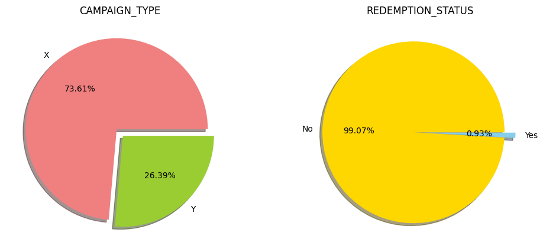

| REDEMPTION_STATUS | CAMPAIGN_TYPE | POPULATION DISTRIBUTION |
| --- | --- | --- |
| 0 | X | 72.794089 |
|  | Y | 26.275696 |
| 1 | X | 0.811545 |
|  | Y | 0.118669 |

- Two campaigns are organized X and Y where campaign X has captured more than 73% of the population and the rest by campaign Y. - Consumers redeemed 0.93% of the total coupons from the given campaign where X represents 0.81% and Y 0.11% redemption rate.

```python
display(Markdown("**We have to figure out the causal impact of coupon redemption based on the campaign done in 2012-13.**  "))

color_pallet = ['lightcoral','yellowgreen', 'gold', 'skyblue']
plt.figure(figsize = (12,5))
plt.subplot(1,2,1)
plt.title('CAMPAIGN_TYPE')
plt.pie(
    train_final['CAMPAIGN_TYPE'].value_counts(True),
    colors = color_pallet[:2], explode = [0.05, 0.05], shadow=True, startangle = 0, autopct = '%.2f%%', labels= ['X', 'Y']
)
plt.subplot(1,2,2)
plt.title('REDEMPTION_STATUS')
plt.pie(
    train_final['REDEMPTION_STATUS'].value_counts(True),
    colors = color_pallet[2:], explode = [0.07, 0.05], shadow=True, startangle = 0, autopct = '%.2f%%', labels= ['No', 'Yes']
)
plt.show()


temp_df = train_final.groupby(['REDEMPTION_STATUS','CAMPAIGN_TYPE'])[['REDEMPTION_STATUS']].count()
temp_df = temp_df.rename(columns = {'REDEMPTION_STATUS': 'POPULATION DISTRIBUTION'})
display((100 * temp_df[['POPULATION DISTRIBUTION']]) / train_final.shape[0])

display(Markdown("- Two campaigns are organized X and Y where campaign X has captured more than 73% of the population and the rest by campaign Y. - Consumers redeemed 0.93% of the total coupons from the given campaign where X represents 0.81% and Y 0.11% redemption rate.  "))
```

## Data Quality Check and Univariate/Bivariate Analysis

```python
final_df = train_final.copy()
display(Markdown("### Data Quality Check"))
dq_df = pd.DataFrame({
    "DATA TYPES": final_df.dtypes,
    "TOTAL COUNT": final_df.count(),
    "FILL RATE": np.round((final_df.count()*100) / final_df.shape[0],2)
}).copy()

dq_df.index.names = ['VARIABLES']
dq_df = dq_df.reset_index()
display(dq_df)

display(Markdown("#### After NULL values treatment"))
final_df['INCOME_BRACKET'].fillna(0, inplace=True) # 0 means not given
final_df['INCOME_BRACKET'] = final_df['INCOME_BRACKET'].astype(str) # income bracket is categorical
final_df['NO_OF_CHILDREN'].fillna('0', inplace=True) # 'NA' means not available
final_df['FAMILY_SIZE'].fillna('NA', inplace=True) # 'NA' means not available

final_df['FAMILY_SIZE'] = np.where(
    (final_df['FAMILY_SIZE'] == 'NA') & (final_df['MARITAL_STATUS'] == 'Married') & (final_df['NO_OF_CHILDREN'] == '0'),
    '2_',
    final_df['FAMILY_SIZE']
)

final_df['FAMILY_SIZE'] = np.where(
    (final_df['FAMILY_SIZE'] == 'NA') & (final_df['MARITAL_STATUS'] == 'Married') & (final_df['NO_OF_CHILDREN'] !='0'),
    '2_' + final_df['NO_OF_CHILDREN'],
    final_df['FAMILY_SIZE']
)

final_df['FAMILY_SIZE'] = np.where(
    (final_df['FAMILY_SIZE'] == 'NA') & (final_df['MARITAL_STATUS'] != 'Married') & (final_df['NO_OF_CHILDREN'] != '0'),
    '1_' + final_df['NO_OF_CHILDREN'],
    final_df['FAMILY_SIZE']
)

final_df['AGE_RANGE'].fillna('NA', inplace=True) # 'NA' means not available
final_df['MARITAL_STATUS'].fillna('NA', inplace=True) # 'NA' means not available

final_df['MARITAL_STATUS'] = np.where((
    (final_df['MARITAL_STATUS'] == 'NA') & (final_df['MARITAL_STATUS'] != '0')), 'Married',
    final_df['MARITAL_STATUS']
)

final_df['DISCONT_PERCENTAGE'] = (1- ((final_df['CUST_TRANS_BY_ITM_MEAN_SELLING_PRICE'] * final_df['CUST_TRANS_BY_ITM_MEAN_QUANITY']) - final_df['CUST_TRANS_BY_ITM_MEAN_QUANITY'])/ (final_df['CUST_TRANS_BY_ITM_MEAN_SELLING_PRICE'] * final_df['CUST_TRANS_BY_ITM_MEAN_QUANITY']))

display(pd.DataFrame((final_df.notna().sum() * 100) // final_df.shape[0]).T)
```

Data Quality Check

|  | VARIABLES | DATA TYPES | TOTAL COUNT | FILL RATE |
| --- | --- | --- | --- | --- |
| 0 | ID | int32 | 78369 | 100.00 |
| 1 | CAMPAIGN_ID | int8 | 78369 | 100.00 |
| 2 | COUPON_ID | int16 | 78369 | 100.00 |
| 3 | CUSTOMER_ID | int16 | 78369 | 100.00 |
| 4 | REDEMPTION_STATUS | int8 | 78369 | 100.00 |
| 5 | BRAND | int16 | 78369 | 100.00 |
| 6 | BRAND_TYPE | object | 78369 | 100.00 |
| 7 | CATEGORY | object | 78369 | 100.00 |
| 8 | CUST_TRANS_BY_ITM_MAX_COUPON_DISCOUNT | float64 | 78369 | 100.00 |
| 9 | CUST_TRANS_BY_ITM_MAX_COUPON_USED | float64 | 78369 | 100.00 |
| 10 | CUST_TRANS_BY_ITM_MAX_NO_OF_CUSTOMERS | float64 | 78369 | 100.00 |
| 11 | CUST_TRANS_BY_ITM_MAX_OTHER_DISCOUNT | float64 | 78369 | 100.00 |
| 12 | CUST_TRANS_BY_ITM_MAX_QUANITY | float64 | 78369 | 100.00 |
| 13 | CUST_TRANS_BY_ITM_MAX_SELLING_PRICE | float64 | 78369 | 100.00 |
| 14 | CUST_TRANS_BY_ITM_MEAN_COUPON_DISCOUNT | float64 | 78369 | 100.00 |
| 15 | CUST_TRANS_BY_ITM_MEAN_COUPON_USED | float64 | 78369 | 100.00 |
| 16 | CUST_TRANS_BY_ITM_MEAN_NO_OF_CUSTOMERS | float64 | 78369 | 100.00 |
| 17 | CUST_TRANS_BY_ITM_MEAN_OTHER_DISCOUNT | float64 | 78369 | 100.00 |
| 18 | CUST_TRANS_BY_ITM_MEAN_QUANITY | float64 | 78369 | 100.00 |
| 19 | CUST_TRANS_BY_ITM_MEAN_SELLING_PRICE | float64 | 78369 | 100.00 |
| 20 | CUST_TRANS_BY_ITM_MIN_COUPON_DISCOUNT | float64 | 78369 | 100.00 |
| 21 | CUST_TRANS_BY_ITM_MIN_COUPON_USED | float64 | 78369 | 100.00 |
| 22 | CUST_TRANS_BY_ITM_MIN_NO_OF_CUSTOMERS | float64 | 78369 | 100.00 |
| 23 | CUST_TRANS_BY_ITM_MIN_OTHER_DISCOUNT | float64 | 78369 | 100.00 |
| 24 | CUST_TRANS_BY_ITM_MIN_QUANITY | float64 | 78369 | 100.00 |
| 25 | CUST_TRANS_BY_ITM_MIN_SELLING_PRICE | float64 | 78369 | 100.00 |
| 26 | CUST_TRANS_BY_ITM_SUM_COUPON_DISCOUNT | float64 | 78369 | 100.00 |
| 27 | CUST_TRANS_BY_ITM_SUM_OTHER_DISCOUNT | float64 | 78369 | 100.00 |
| 28 | CUST_TRANS_BY_ITM_SUM_QUANTITY | float64 | 78369 | 100.00 |
| 29 | CUST_TRANS_BY_ITM_SUM_SELLING_PRICE | float64 | 78369 | 100.00 |
| 30 | CUST_TRANS_BY_ITM_SUM_TRANS_COUNTS | float64 | 78369 | 100.00 |
| 31 | ITEM_COUNTS | int64 | 78369 | 100.00 |
| 32 | TOTAL_DISCOUNT_MEAN | float64 | 78369 | 100.00 |
| 33 | TOTAL_DISCOUNT_SUM | float64 | 78369 | 100.00 |
| 34 | CAMPAIGN_TYPE | object | 78369 | 100.00 |
| 35 | START_DATE | object | 78369 | 100.00 |
| 36 | END_DATE | object | 78369 | 100.00 |
| 37 | AGE_RANGE | object | 43661 | 55.71 |
| 38 | MARITAL_STATUS | object | 25394 | 32.40 |
| 39 | RENTED | float64 | 78369 | 100.00 |
| 40 | FAMILY_SIZE | object | 43661 | 55.71 |
| 41 | NO_OF_CHILDREN | object | 14056 | 17.94 |
| 42 | INCOME_BRACKET | float64 | 43661 | 55.71 |
| 43 | COUPON_DISCOUNT | float64 | 78369 | 100.00 |
| 44 | COUPON_USED | int64 | 78369 | 100.00 |
| 45 | DAY | int64 | 78369 | 100.00 |
| 46 | DAYOFWEEK | int64 | 78369 | 100.00 |
| 47 | NO_OF_ITEMS | int64 | 78369 | 100.00 |
| 48 | MONTH | int64 | 78369 | 100.00 |
| 49 | OTHER_DISCOUNT | float64 | 78369 | 100.00 |
| 50 | QUANTITY | float64 | 78369 | 100.00 |
| 51 | SELLING_PRICE | float64 | 78369 | 100.00 |
| 52 | YEAR | int64 | 78369 | 100.00 |
| 53 | CUST_ID_SUM_COUPON_DISCOUNT | float64 | 78369 | 100.00 |
| 54 | CUSTOMER_ID_COUNT | int64 | 78369 | 100.00 |
| 55 | CUST_ID_SUM_OTHER_DISCOUNT | float64 | 78369 | 100.00 |
| 56 | CUST_ID_SUM_QUANTITY | int32 | 78369 | 100.00 |
| 57 | CUST_ID_SUM_SELLING_PRICE | float64 | 78369 | 100.00 |

After NULL values treatment

|  | ID | CAMPAIGN_ID | COUPON_ID | CUSTOMER_ID | REDEMPTION_STATUS | BRAND | BRAND_TYPE | CATEGORY | CUST_TRANS_BY_ITM_MAX_COUPON_DISCOUNT | CUST_TRANS_BY_ITM_MAX_COUPON_USED | CUST_TRANS_BY_ITM_MAX_NO_OF_CUSTOMERS | CUST_TRANS_BY_ITM_MAX_OTHER_DISCOUNT | CUST_TRANS_BY_ITM_MAX_QUANITY | CUST_TRANS_BY_ITM_MAX_SELLING_PRICE | CUST_TRANS_BY_ITM_MEAN_COUPON_DISCOUNT | CUST_TRANS_BY_ITM_MEAN_COUPON_USED | CUST_TRANS_BY_ITM_MEAN_NO_OF_CUSTOMERS | CUST_TRANS_BY_ITM_MEAN_OTHER_DISCOUNT | CUST_TRANS_BY_ITM_MEAN_QUANITY | CUST_TRANS_BY_ITM_MEAN_SELLING_PRICE | CUST_TRANS_BY_ITM_MIN_COUPON_DISCOUNT | CUST_TRANS_BY_ITM_MIN_COUPON_USED | CUST_TRANS_BY_ITM_MIN_NO_OF_CUSTOMERS | CUST_TRANS_BY_ITM_MIN_OTHER_DISCOUNT | CUST_TRANS_BY_ITM_MIN_QUANITY | ... | CAMPAIGN_TYPE | START_DATE | END_DATE | … |
| --- | --- | --- | --- | --- | --- | --- | --- | --- | --- | --- | --- | --- | --- | --- | --- | --- | --- | --- | --- | --- | --- | --- | --- | --- | --- | --- | --- | --- | --- | --- |
| 0 | 100 | 100 | 100 | 100 | 100 | 100 | 100 | 100 | 100 | 100 | 100 | 100 | 100 | 100 | 100 | 100 | 100 | 100 | 100 | 100 | 100 | 100 | 100 | 100 | 100 | ... | 100 | 100 | 100 | … |

1 rows × 59 columns

```python
display(Markdown("### Univariate Analysis"))
from scipy.stats import skew, kurtosis
temp_df = final_df[final_df.dtypes[final_df.dtypes != 'object'].index]
skew_kurt_df = pd.DataFrame({
    'Skewness': skew(temp_df, axis=0, bias=True),
    'Kurtosis': kurtosis(temp_df, axis=0, bias=True)}, index = temp_df.columns)
univar_df = final_df.describe(np.arange(0,1,0.05)).T.merge(skew_kurt_df, left_index=True, right_index=True)
display(univar_df)
```

Univariate Analysis

|  | count | mean | std | min | 0% | 5% | 10% | 15% | 20% | 25% | 30% | 35% | 40% | 45% | 50% | 55% | 60% | 65% | 70% | 75% | 80% | 85% | 90% | 95% | max | Skewness | Kurtosis |
| --- | --- | --- | --- | --- | --- | --- | --- | --- | --- | --- | --- | --- | --- | --- | --- | --- | --- | --- | --- | --- | --- | --- | --- | --- | --- | --- | --- |
| ID | 78369.0 | 64347.975449 | 3.712644e+04 | 1.000000e+00 | 1.000000e+00 | 6551.800000 | 12983.600000 | 19391.200000 | 25861.600000 | 32260.000000 | 38547.400000 | 45005.200000 | 51374.200000 | 57805.600000 | 64318.000000 | 70692.800000 | 77051.600000 | 83534.200000 | 90152.600000 | 96577.000000 | 103049.400000 | 109347.800000 | 115869.400000 | 122253.200000 | 1.285950e+05 | 0.002568 | -1.201291 |
| CAMPAIGN_ID | 78369.0 | 13.974441 | 8.019215e+00 | 1.000000e+00 | 1.000000e+00 | 5.000000 | 8.000000 | 8.000000 | 8.000000 | 8.000000 | 8.000000 | 8.000000 | 9.000000 | 11.000000 | 13.000000 | 13.000000 | 13.000000 | 13.000000 | 13.000000 | 13.000000 | 26.000000 | 26.000000 | 29.000000 | 30.000000 | 3.000000e+01 | 1.037823 | -0.339932 |
| COUPON_ID | 78369.0 | 566.363243 | 3.299661e+02 | 1.000000e+00 | 1.000000e+00 | 53.000000 | 90.000000 | 124.000000 | 160.000000 | 280.000000 | 365.000000 | 440.000000 | 481.000000 | 535.000000 | 597.000000 | 645.000000 | 691.000000 | 738.000000 | 783.000000 | 857.000000 | 909.000000 | 961.000000 | 1007.000000 | 1055.000000 | 1.115000e+03 | -0.132474 | -1.194704 |
| CUSTOMER_ID | 78369.0 | 787.451888 | 4.568113e+02 | 1.000000e+00 | 1.000000e+00 | 80.000000 | 162.000000 | 235.000000 | 316.000000 | 399.000000 | 467.000000 | 551.000000 | 624.000000 | 698.000000 | 781.000000 | 860.000000 | 942.000000 | 1025.000000 | 1100.600000 | 1190.000000 | 1271.000000 | 1348.000000 | 1420.000000 | 1496.000000 | 1.582000e+03 | 0.020233 | -1.204471 |
| REDEMPTION_STATUS | 78369.0 | 0.009302 | 9.599862e-02 | 0.000000e+00 | 0.000000e+00 | 0.000000 | 0.000000 | 0.000000 | 0.000000 | 0.000000 | 0.000000 | 0.000000 | 0.000000 | 0.000000 | 0.000000 | 0.000000 | 0.000000 | 0.000000 | 0.000000 | 0.000000 | 0.000000 | 0.000000 | 0.000000 | 0.000000 | 1.000000e+00 | 10.223084 | 102.511447 |
| BRAND | 78369.0 | 1053.349067 | 1.332569e+03 | 1.000000e+00 | 1.000000e+00 | 56.000000 | 56.000000 | 56.000000 | 56.000000 | 58.000000 | 172.000000 | 248.000000 | 406.000000 | 524.000000 | 681.000000 | 782.000000 | 914.000000 | 989.000000 | 1105.000000 | 1193.000000 | 1470.000000 | 1808.000000 | 2812.400000 | 4437.000000 | 5.395000e+03 | 1.916782 | 2.816458 |
| CUST_TRANS_BY_ITM_MAX_COUPON_DISCOUNT | 78369.0 | -0.119083 | 2.842685e+00 | -7.124000e+01 | -7.124000e+01 | 0.000000 | 0.000000 | 0.000000 | 0.000000 | 0.000000 | 0.000000 | 0.000000 | 0.000000 | 0.000000 | 0.000000 | 0.000000 | 0.000000 | 0.000000 | 0.000000 | 0.000000 | 0.000000 | 0.000000 | 0.000000 | 0.000000 | 0.000000e+00 | -24.376683 | 599.409610 |
| CUST_TRANS_BY_ITM_MAX_COUPON_USED | 78369.0 | 0.684084 | 4.648825e-01 | 0.000000e+00 | 0.000000e+00 | 0.000000 | 0.000000 | 0.000000 | 0.000000 | 0.000000 | 0.000000 | 1.000000 | 1.000000 | 1.000000 | 1.000000 | 1.000000 | 1.000000 | 1.000000 | 1.000000 | 1.000000 | 1.000000 | 1.000000 | 1.000000 | 1.000000 | 1.000000e+00 | -0.791965 | -1.372791 |
| CUST_TRANS_BY_ITM_MAX_NO_OF_CUSTOMERS | 78369.0 | 77.270987 | 1.028761e+02 | 1.000000e+00 | 1.000000e+00 | 3.000000 | 6.000000 | 9.000000 | 13.000000 | 16.000000 | 22.000000 | 24.000000 | 29.000000 | 36.000000 | 42.000000 | 52.000000 | 60.000000 | 68.000000 | 79.000000 | 93.000000 | 113.000000 | 147.000000 | 187.000000 | 289.000000 | 9.050000e+02 | 3.331261 | 16.376960 |
| CUST_TRANS_BY_ITM_MAX_OTHER_DISCOUNT | 78369.0 | -0.808729 | 7.591582e+00 | -2.707100e+02 | -2.707100e+02 | 0.000000 | 0.000000 | 0.000000 | 0.000000 | 0.000000 | 0.000000 | 0.000000 | 0.000000 | 0.000000 | 0.000000 | 0.000000 | 0.000000 | 0.000000 | 0.000000 | 0.000000 | 0.000000 | 0.000000 | 0.000000 | 0.000000 | 0.000000e+00 | -22.744651 | 730.556749 |
| CUST_TRANS_BY_ITM_MAX_QUANITY | 78369.0 | 5.352971 | 5.717843e+00 | 1.000000e+00 | 1.000000e+00 | 1.000000 | 1.000000 | 2.000000 | 2.000000 | 2.000000 | 2.000000 | 3.000000 | 3.000000 | 3.000000 | 4.000000 | 4.000000 | 4.000000 | 5.000000 | 5.000000 | 6.000000 | 7.000000 | 9.000000 | 10.000000 | 16.000000 | 5.400000e+01 | 3.466851 | 16.607467 |
| CUST_TRANS_BY_ITM_MAX_SELLING_PRICE | 78369.0 | 567.221928 | 8.461783e+02 | 6.340000e+01 | 6.340000e+01 | 141.770000 | 178.100000 | 213.360000 | 234.380000 | 255.750000 | 284.960000 | 319.510000 | 355.490000 | 356.200000 | 373.300000 | 410.340000 | 427.080000 | 469.470000 | 533.230000 | 601.980000 | 681.770000 | 765.120000 | 958.530000 | 1352.850000 | 1.156760e+04 | 8.106876 | 86.492687 |
| CUST_TRANS_BY_ITM_MEAN_COUPON_DISCOUNT | 78369.0 | -2.265920 | 5.814932e+00 | -7.124000e+01 | -7.124000e+01 | -9.711288 | -4.826531 | -3.674231 | -2.802776 | -2.101764 | -1.660852 | -1.261337 | -1.073398 | -0.768225 | -0.608013 | -0.308263 | -0.171454 | -0.036365 | 0.000000 | 0.000000 | 0.000000 | 0.000000 | 0.000000 | 0.000000 | 0.000000e+00 | -6.216784 | 50.959506 |
| CUST_TRANS_BY_ITM_MEAN_COUPON_USED | 78369.0 | 0.050723 | 9.106553e-02 | 0.000000e+00 | 0.000000e+00 | 0.000000 | 0.000000 | 0.000000 | 0.000000 | 0.000000 | 0.000000 | 0.001118 | 0.005263 | 0.008511 | 0.017217 | 0.025996 | 0.031084 | 0.042427 | 0.054487 | 0.067151 | 0.080753 | 0.099743 | 0.127206 | 0.200454 | 1.000000e+00 | 4.396939 | 30.092795 |
| CUST_TRANS_BY_ITM_MEAN_NO_OF_CUSTOMERS | 78369.0 | 17.538716 | 1.349744e+01 | 1.000000e+00 | 1.000000e+00 | 2.000000 | 3.000000 | 4.375000 | 5.428571 | 7.200000 | 8.583333 | 10.100000 | 12.000000 | 13.666667 | 15.000000 | 16.714286 | 18.437500 | 20.400000 | 22.250000 | 24.333333 | 27.000000 | 29.833333 | 35.625000 | 42.000000 | 1.185714e+02 | 1.517082 | 4.641715 |
| CUST_TRANS_BY_ITM_MEAN_OTHER_DISCOUNT | 78369.0 | -24.627777 | 2.686256e+01 | -7.331300e+02 | -7.331300e+02 | -66.985439 | -51.037619 | -43.034814 | -36.638694 | -32.240629 | -27.578633 | -24.942487 | -22.180050 | -19.945283 | -17.999941 | -16.670000 | -15.034330 | -13.134295 | -11.459700 | -9.455043 | -8.435480 | -6.680978 | -4.656923 | -1.575932 | 0.000000e+00 | -9.526593 | 219.124834 |
| CUST_TRANS_BY_ITM_MEAN_QUANITY | 78369.0 | 1.173147 | 2.646552e-01 | 1.000000e+00 | 1.000000e+00 | 1.000000 | 1.000000 | 1.017143 | 1.024539 | 1.032746 | 1.045161 | 1.058848 | 1.071113 | 1.080000 | 1.095333 | 1.110390 | 1.127816 | 1.149693 | 1.174367 | 1.202614 | 1.245587 | 1.290094 | 1.408654 | 1.599656 | 4.096092e+00 | 4.719749 | 34.240132 |
| CUST_TRANS_BY_ITM_MEAN_SELLING_PRICE | 78369.0 | 153.914308 | 1.387027e+02 | 2.361650e+01 | 2.361650e+01 | 44.319442 | 55.017273 | 67.850599 | 76.542190 | 85.108789 | 91.918332 | 98.258847 | 102.940000 | 108.072602 | 113.166224 | 121.422458 | 127.968935 | 135.004724 | 152.035083 | 173.600912 | 188.430000 | 229.883846 | 286.353023 | 391.460000 | 1.275898e+03 | 3.556444 | 16.959483 |
| CUST_TRANS_BY_ITM_MIN_COUPON_DISCOUNT | 78369.0 | -69.591646 | 1.646186e+02 | -1.992230e+03 | -1.992230e+03 | -191.990000 | -142.480000 | -106.860000 | -99.380000 | -71.240000 | -71.240000 | -60.200000 | -53.430000 | -39.180000 | -35.620000 | -35.620000 | -35.620000 | -19.590000 | 0.000000 | 0.000000 | 0.000000 | 0.000000 | 0.000000 | 0.000000 | 0.000000e+00 | -8.761302 | 93.247947 |
| CUST_TRANS_BY_ITM_MIN_COUPON_USED | 78369.0 | 0.001825 | 4.267780e-02 | 0.000000e+00 | 0.000000e+00 | 0.000000 | 0.000000 | 0.000000 | 0.000000 | 0.000000 | 0.000000 | 0.000000 | 0.000000 | 0.000000 | 0.000000 | 0.000000 | 0.000000 | 0.000000 | 0.000000 | 0.000000 | 0.000000 | 0.000000 | 0.000000 | 0.000000 | 1.000000e+00 | 23.346023 | 543.036793 |
| CUST_TRANS_BY_ITM_MIN_NO_OF_CUSTOMERS | 78369.0 | 2.288354 | 5.482097e+00 | 1.000000e+00 | 1.000000e+00 | 1.000000 | 1.000000 | 1.000000 | 1.000000 | 1.000000 | 1.000000 | 1.000000 | 1.000000 | 1.000000 | 1.000000 | 1.000000 | 1.000000 | 1.000000 | 1.000000 | 1.000000 | 1.000000 | 1.000000 | 2.000000 | 11.000000 | 5.200000e+01 | 6.278334 | 45.302226 |
| CUST_TRANS_BY_ITM_MIN_OTHER_DISCOUNT | 78369.0 | -198.884174 | 2.552301e+02 | -3.097870e+03 | -3.097870e+03 | -602.690000 | -425.300000 | -326.280000 | -272.140000 | -242.220000 | -212.300000 | -178.100000 | -158.510000 | -141.060000 | -126.810000 | -112.560000 | -106.500000 | -95.460000 | -75.870000 | -70.530000 | -56.990000 | -42.740000 | -35.620000 | -21.370000 | 0.000000e+00 | -5.143617 | 41.072599 |
| CUST_TRANS_BY_ITM_MIN_QUANITY | 78369.0 | 1.000000 | 0.000000e+00 | 1.000000e+00 | 1.000000e+00 | 1.000000 | 1.000000 | 1.000000 | 1.000000 | 1.000000 | 1.000000 | 1.000000 | 1.000000 | 1.000000 | 1.000000 | 1.000000 | 1.000000 | 1.000000 | 1.000000 | 1.000000 | 1.000000 | 1.000000 | 1.000000 | 1.000000 | 1.000000e+00 | NaN | NaN |
| CUST_TRANS_BY_ITM_MIN_SELLING_PRICE | 78369.0 | 82.948948 | 9.976967e+01 | 3.600000e-01 | 3.600000e-01 | 5.700000 | 15.670000 | 19.590000 | 26.710000 | 35.260000 | 35.620000 | 35.620000 | 47.730000 | 53.430000 | 56.640000 | 62.330000 | 70.530000 | 71.240000 | 88.690000 | 92.260000 | 106.860000 | 138.560000 | 173.830000 | 231.170000 | 9.613800e+02 | 4.161328 | 23.888485 |
| CUST_TRANS_BY_ITM_SUM_COUPON_DISCOUNT | 78369.0 | -1410.408817 | 7.152120e+03 | -1.136273e+05 | -1.136273e+05 | -4819.010000 | -2131.880000 | -1374.830000 | -1006.180000 | -756.560000 | -585.970000 | -491.560000 | -365.050000 | -284.960000 | -213.720000 | -142.480000 | -73.020000 | -35.620000 | 0.000000 | 0.000000 | 0.000000 | 0.000000 | 0.000000 | 0.000000 | 0.000000e+00 | -11.461555 | 146.968161 |
| CUST_TRANS_BY_ITM_SUM_OTHER_DISCOUNT | 78369.0 | -44812.711031 | 2.856084e+05 | -4.049765e+06 | -4.049765e+06 | -108727.810000 | -51938.500000 | -29456.130000 | -20752.830000 | -14603.370000 | -11999.840000 | -9919.560000 | -7079.770000 | -5412.620000 | -4614.410000 | -3708.880000 | -2768.370000 | -2182.950000 | -1695.600000 | -1154.780000 | -808.470000 | -493.670000 | -213.730000 | -60.540000 | 0.000000e+00 | -10.811060 | 123.094053 |
| CUST_TRANS_BY_ITM_SUM_QUANTITY | 78369.0 | 2627.562748 | 1.580119e+04 | 1.000000e+00 | 1.000000e+00 | 9.000000 | 22.000000 | 43.000000 | 60.000000 | 103.000000 | 134.000000 | 160.000000 | 210.000000 | 263.000000 | 323.000000 | 394.000000 | 456.000000 | 591.000000 | 767.000000 | 986.000000 | 1402.000000 | 1713.000000 | 2872.000000 | 5365.000000 | 2.075790e+05 | 10.058150 | 108.553091 |
| CUST_TRANS_BY_ITM_SUM_SELLING_PRICE | 78369.0 | 214997.599015 | 1.279635e+06 | 7.088000e+01 | 7.088000e+01 | 1677.660000 | 3591.540000 | 5552.730000 | 8917.750000 | 11310.410000 | 13997.920000 | 18386.580000 | 21498.210000 | 25464.880000 | 30249.280000 | 36214.180000 | 44943.980000 | 54357.930000 | 68081.030000 | 90162.100000 | 120062.830000 | 156327.070000 | 197735.800000 | 359510.540000 | 1.555707e+07 | 9.512837 | 92.904112 |
| CUST_TRANS_BY_ITM_SUM_TRANS_COUNTS | 78369.0 | 2031.808802 | 1.194151e+04 | 1.000000e+00 | 1.000000e+00 | 8.000000 | 21.000000 | 38.000000 | 58.000000 | 86.000000 | 116.000000 | 142.000000 | 177.000000 | 218.000000 | 279.000000 | 332.000000 | 389.000000 | 474.000000 | 662.000000 | 857.000000 | 1126.000000 | 1375.000000 | 2242.000000 | 3797.000000 | 1.587880e+05 | 9.956884 | 106.746720 |
| ITEM_COUNTS | 78369.0 | 81.929003 | 6.050325e+02 | 1.000000e+00 | 1.000000e+00 | 1.000000 | 3.000000 | 3.000000 | 4.000000 | 5.000000 | 6.000000 | 7.000000 | 8.000000 | 10.000000 | 12.000000 | 14.000000 | 16.000000 | 19.000000 | 24.000000 | 30.000000 | 37.000000 | 50.000000 | 65.000000 | 93.000000 | 1.181300e+04 | 13.981466 | 235.711393 |
| TOTAL_DISCOUNT_MEAN | 78369.0 | -26.893697 | 2.816488e+01 | -7.604387e+02 | -7.604387e+02 | -74.183287 | -54.898620 | -46.594454 | -39.855000 | -35.113080 | -31.175213 | -26.905109 | -24.321323 | -21.927851 | -20.184006 | -17.999941 | -16.508478 | -14.426971 | -12.665760 | -10.775942 | -9.254223 | -7.392162 | -5.100854 | -2.709322 | 0.000000e+00 | -9.123882 | 207.705486 |
| TOTAL_DISCOUNT_SUM | 78369.0 | -46223.119848 | 2.912581e+05 | -4.134328e+06 | -4.134328e+06 | -108747.400000 | -52939.140000 | -30704.720000 | -21558.130000 | -16730.610000 | -12621.410000 | -10736.540000 | -7382.120000 | -6120.320000 | -4899.570000 | -4045.070000 | -3144.708000 | -2450.180000 | -1912.760000 | -1496.020000 | -900.470000 | -569.920000 | -252.840000 | -92.980000 | 0.000000e+00 | -10.755135 | 121.950603 |
| RENTED | 78369.0 | 0.031964 | 1.759058e-01 | 0.000000e+00 | 0.000000e+00 | 0.000000 | 0.000000 | 0.000000 | 0.000000 | 0.000000 | 0.000000 | 0.000000 | 0.000000 | 0.000000 | 0.000000 | 0.000000 | 0.000000 | 0.000000 | 0.000000 | 0.000000 | 0.000000 | 0.000000 | 0.000000 | 0.000000 | 1.000000e+00 | 5.321471 | 26.318050 |
| COUPON_DISCOUNT | 78369.0 | -0.624218 | 1.104607e+00 | -1.362908e+01 | -1.362908e+01 | -2.573914 | -1.628325 | -1.189544 | -0.885435 | -0.705638 | -0.563487 | -0.461177 | -0.375982 | -0.304444 | -0.242455 | -0.191590 | -0.155226 | -0.115222 | -0.080955 | -0.055656 | -0.034405 | 0.000000 | 0.000000 | 0.000000 | 0.000000e+00 | -4.753111 | 36.571853 |
| COUPON_USED | 78369.0 | 18.391430 | 3.866283e+01 | 0.000000e+00 | 0.000000e+00 | 0.000000 | 0.000000 | 0.000000 | 1.000000 | 1.000000 | 2.000000 | 2.000000 | 3.000000 | 4.000000 | 5.000000 | 6.000000 | 8.000000 | 10.000000 | 13.000000 | 17.000000 | 24.000000 | 33.000000 | 47.000000 | 79.000000 | 4.300000e+02 | 4.878114 | 33.320659 |
| DAY | 78369.0 | 15.447396 | 8.528451e+00 | 1.000000e+00 | 1.000000e+00 | 2.000000 | 3.000000 | 5.000000 | 7.000000 | 9.000000 | 10.000000 | 12.000000 | 13.000000 | 14.000000 | 15.000000 | 16.000000 | 18.000000 | 20.000000 | 21.000000 | 23.000000 | 24.000000 | 26.000000 | 28.000000 | 29.000000 | 3.100000e+01 | 0.003553 | -1.074505 |
| DAYOFWEEK | 78369.0 | 3.204022 | 1.715666e+00 | 0.000000e+00 | 0.000000e+00 | 0.000000 | 1.000000 | 1.000000 | 2.000000 | 2.000000 | 2.000000 | 3.000000 | 3.000000 | 3.000000 | 3.000000 | 4.000000 | 4.000000 | 4.000000 | 4.000000 | 4.000000 | 5.000000 | 5.000000 | 5.000000 | 6.000000 | 6.000000e+00 | -0.265397 | -0.733724 |
| NO_OF_ITEMS | 78369.0 | 592.887417 | 3.238998e+02 | 4.700000e+01 | 4.700000e+01 | 190.000000 | 247.000000 | 291.000000 | 329.000000 | 360.000000 | 396.000000 | 431.000000 | 464.000000 | 495.000000 | 533.000000 | 570.000000 | 607.000000 | 657.000000 | 702.000000 | 745.000000 | 824.000000 | 915.000000 | 1011.000000 | 1200.000000 | 2.432000e+03 | 1.334818 | 3.077457 |
| MONTH | 78369.0 | 4.952826 | 2.333143e+00 | 1.000000e+00 | 1.000000e+00 | 1.000000 | 2.000000 | 3.000000 | 3.000000 | 3.000000 | 4.000000 | 4.000000 | 4.000000 | 5.000000 | 5.000000 | 5.000000 | 5.000000 | 5.000000 | 6.000000 | 6.000000 | 6.000000 | 6.000000 | 8.000000 | 10.000000 | 1.200000e+01 | 0.897989 | 1.221602 |
| OTHER_DISCOUNT | 78369.0 | -18.273669 | 8.666128e+00 | -1.911881e+02 | -1.911881e+02 | -29.335843 | -25.347383 | -23.478749 | -22.077672 | -20.866231 | -19.693625 | -18.835994 | -18.144645 | -17.525987 | -16.724106 | -16.219458 | -15.664775 | -15.127455 | -14.435743 | -13.897148 | -13.461507 | -12.786613 | -11.929772 | -10.615118 | -4.674406e+00 | -8.961553 | 153.562360 |
| QUANTITY | 78369.0 | 128.055506 | 2.161972e+02 | 1.042453e+00 | 1.042453e+00 | 1.159091 | 1.209544 | 1.263374 | 1.319033 | 1.403756 | 1.594833 | 7.803824 | 15.420699 | 27.180505 | 39.755390 | 58.919067 | 83.170807 | 112.044406 | 155.018203 | 190.594817 | 238.632694 | 283.505415 | 376.187702 | 477.922086 | 3.490059e+03 | 6.495944 | 84.365502 |
| SELLING_PRICE | 78369.0 | 116.003809 | 3.157653e+01 | 4.773919e+01 | 4.773919e+01 | 76.300990 | 84.089990 | 88.812200 | 92.841316 | 95.877243 | 99.423932 | 101.753664 | 104.926231 | 108.258346 | 111.057371 | 114.923654 | 118.736653 | 122.165703 | 126.678462 | 130.539012 | 135.613967 | 141.892712 | 150.009155 | 166.689500 | 3.877179e+02 | 2.302527 | 13.177977 |
| YEAR | 78369.0 | 2012.093277 | 2.908216e-01 | 2.012000e+03 | 2.012000e+03 | 2012.000000 | 2012.000000 | 2012.000000 | 2012.000000 | 2012.000000 | 2012.000000 | 2012.000000 | 2012.000000 | 2012.000000 | 2012.000000 | 2012.000000 | 2012.000000 | 2012.000000 | 2012.000000 | 2012.000000 | 2012.000000 | 2012.000000 | 2012.000000 | 2013.000000 | 2.013000e+03 | 2.797082 | 5.823666 |
| CUST_ID_SUM_COUPON_DISCOUNT | 78369.0 | -670.316295 | 1.275994e+03 | -1.193780e+04 | -1.193780e+04 | -2863.090000 | -1748.210000 | -1198.600000 | -944.980000 | -719.510000 | -525.370000 | -436.330000 | -327.690000 | -263.570000 | -224.400000 | -178.100000 | -135.350000 | -97.950000 | -71.240000 | -39.180000 | -26.710000 | 0.000000 | 0.000000 | 0.000000 | 0.000000e+00 | -4.156175 | 22.729584 |
| CUSTOMER_ID_COUNT | 78369.0 | 1032.534752 | 6.580651e+02 | 8.300000e+01 | 8.300000e+01 | 279.000000 | 377.000000 | 446.000000 | 509.000000 | 557.000000 | 610.000000 | 669.000000 | 740.000000 | 808.000000 | 884.000000 | 970.000000 | 1047.000000 | 1116.000000 | 1222.000000 | 1335.000000 | 1468.200000 | 1671.000000 | 1911.000000 | 2346.000000 | 4.522000e+03 | 1.513220 | 3.366802 |
| CUST_ID_SUM_OTHER_DISCOUNT | 78369.0 | -18440.669741 | 1.304517e+04 | -1.014283e+05 | -1.014283e+05 | -44107.040000 | -34894.840000 | -30363.880000 | -26214.130000 | -23509.230000 | -21752.540000 | -19980.820000 | -18439.730000 | -16619.150000 | -15290.490000 | -14065.770000 | -12853.470000 | -11472.350000 | -10318.690000 | -9294.290000 | -8227.920000 | -7030.680000 | -5659.720000 | -4186.340000 | -7.348000e+02 | -1.833254 | 5.469398 |
| CUST_ID_SUM_QUANTITY | 78369.0 | 141279.442420 | 2.414470e+05 | 8.800000e+01 | 8.800000e+01 | 489.000000 | 646.000000 | 832.000000 | 1135.000000 | 1593.000000 | 2270.000000 | 6529.000000 | 12618.000000 | 18793.000000 | 31641.000000 | 49692.000000 | 73649.000000 | 103675.000000 | 142095.000000 | 184709.000000 | 241023.000000 | 316443.000000 | 437063.000000 | 630593.000000 | 2.617544e+06 | 3.409985 | 19.480993 |
| CUST_ID_SUM_SELLING_PRICE | 78369.0 | 119180.270731 | 8.190162e+04 | 8.338540e+03 | 8.338540e+03 | 30373.000000 | 39268.650000 | 47445.860000 | 53719.010000 | 59205.590000 | 65267.310000 | 73388.200000 | 82019.460000 | 90550.310000 | 98840.740000 | 107185.140000 | 116085.530000 | 129142.270000 | 138297.030000 | 155596.980000 | 169717.930000 | 194678.780000 | 230112.410000 | 288774.740000 | 5.836388e+05 | 1.558037 | 3.165228 |
| DISCONT_PERCENTAGE | 78369.0 | 0.009932 | 6.333292e-03 | 7.837619e-04 | 7.837619e-04 | 0.002555 | 0.003492 | 0.004350 | 0.005307 | 0.005760 | 0.006577 | 0.007407 | 0.007814 | 0.008236 | 0.008837 | 0.009253 | 0.009714 | 0.010177 | 0.010879 | 0.011750 | 0.013065 | 0.014738 | 0.018176 | 0.022563 | 4.234327e-02 | 1.813490 | 4.701821 |

#### Trend Analysis

Categorical Variables wise Redemption Rate Distributions for both Campaigns

**NOTE:** Tilted values describes Redemption Status 0 and vertical values 1.

BRAND_TYPE

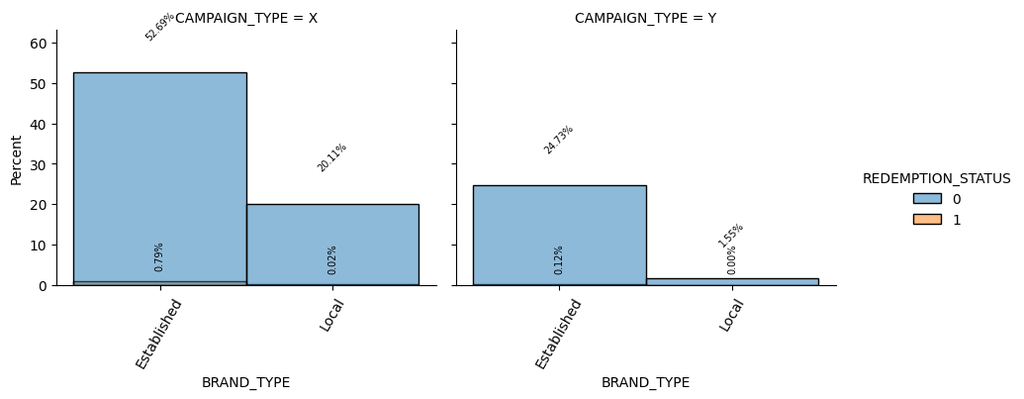

CATEGORY

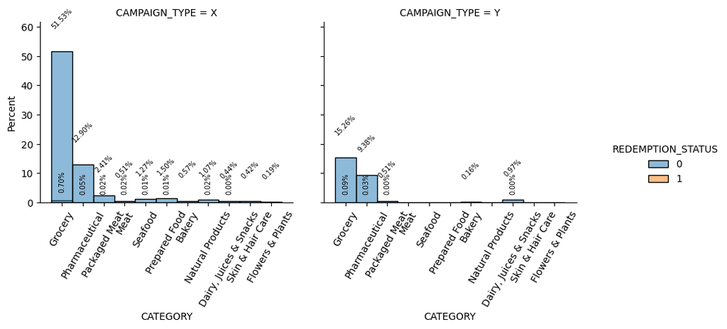

AGE_RANGE

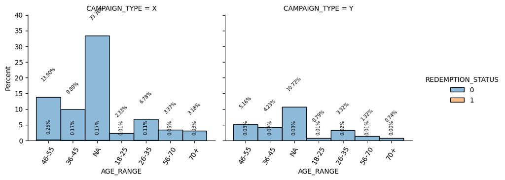

MARITAL_STATUS

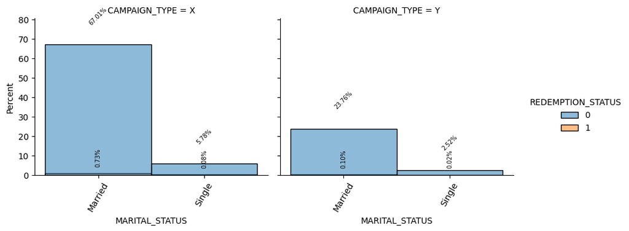

FAMILY_SIZE

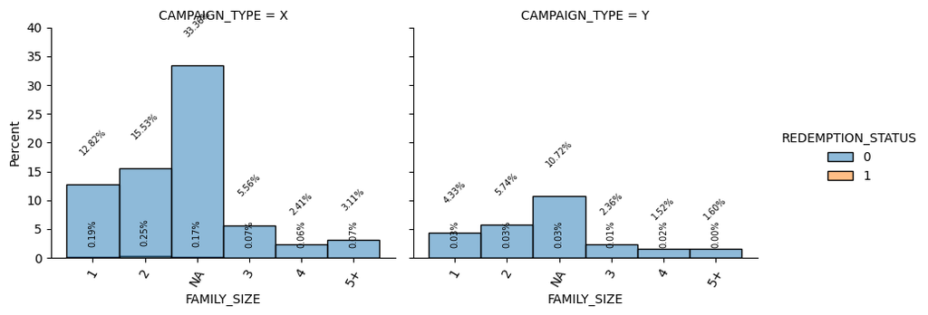

NO_OF_CHILDREN

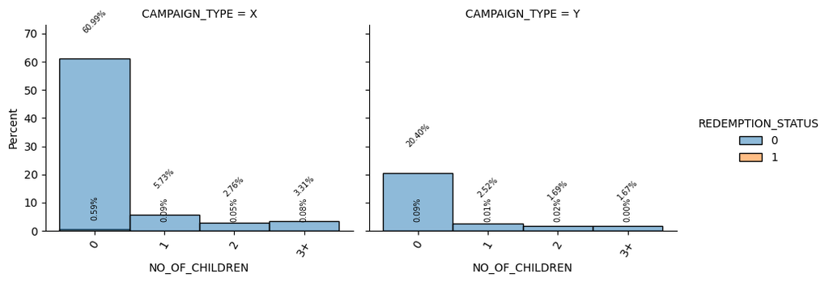

INCOME_BRACKET

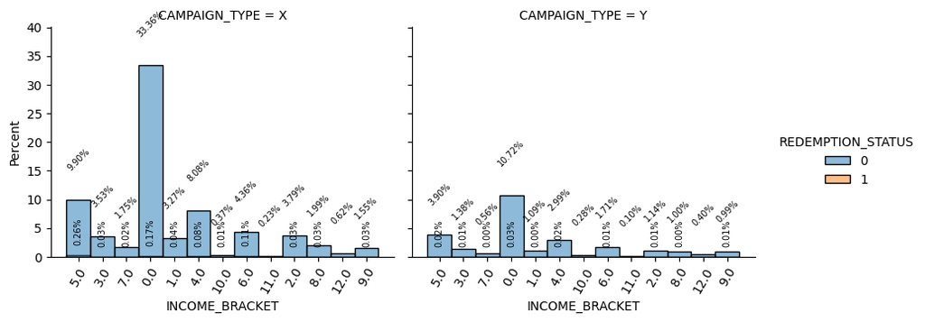

```python
display(Markdown("""
### Categorical Variables wise Redemption Rate Distributions for both Campaigns
**NOTE:** Tilted values describes Redemption Status 0 and vertical values 1.
"""))

catorical_cols_to_display = ['BRAND_TYPE', 'CATEGORY', 'AGE_RANGE', 'MARITAL_STATUS',
                             'FAMILY_SIZE', 'NO_OF_CHILDREN', 'INCOME_BRACKET']

for col in catorical_cols_to_display:
    display(Markdown("#### {} ".format(col)))
    fg = sns.displot(data = final_df, x = col ,hue='REDEMPTION_STATUS', col='CAMPAIGN_TYPE', stat='percent', height=3.5, aspect=1.25)
    fg.set_xticklabels(rotation=60)
    for ax in fg.axes.ravel():
        # add annotations
        cnt = 0
        for c in ax.containers:
            # custom label calculates percent and add an empty string so 0 value bars don't have a number
            labels = [f'{w:0.2f}%' if (w := v.get_height()) > 0 else '' for v in c]
            if cnt == 0:
                ax.bar_label(c, labels=labels, label_type='edge', fontsize=7, rotation=90, padding=8) # redemption status = 1
            else:
                ax.bar_label(c, labels=labels, label_type='edge', fontsize=7, rotation=45, padding=22) # redemption status = 0
            cnt += 1
        ax.margins(y=0.2)
    plt.show()
```

REDEMPTION TREND DISTRIBUTION FOR BOTH YEARS 2012 & 2013.

| YEAR MONTH | 2012 Apr | 2012 Aug | 2012 Dec | 2012 Feb | 2012 Jan | 2012 Jul | 2012 Jun | 2012 Mar | 2012 May | 2012 Nov | 2012 Oct | 2012 Sep | 2013 Apr | 2013 Dec | 2013 Feb | 2013 Jan | 2013 Jul | 2013 Jun | 2013 Mar | 2013 May | 2013 Nov | 2013 Oct | 2013 Sep |
| --- | --- | --- | --- | --- | --- | --- | --- | --- | --- | --- | --- | --- | --- | --- | --- | --- | --- | --- | --- | --- | --- | --- | --- |
| REDEMPTION RATE | 0.751293 | 0.070771 | 0.076805 | 0.613887 | 1.025776 | 0.429799 | 0.808625 | 0.89132 | 1.650054 | 0.062933 | 0.418605 | 0.0 | 0.396197 | 0.4 | 0.858369 | 2.269289 | 0.0 | 0.157604 | 1.289768 | 0.984529 | 0.0 | 1.785714 | 0.0 |

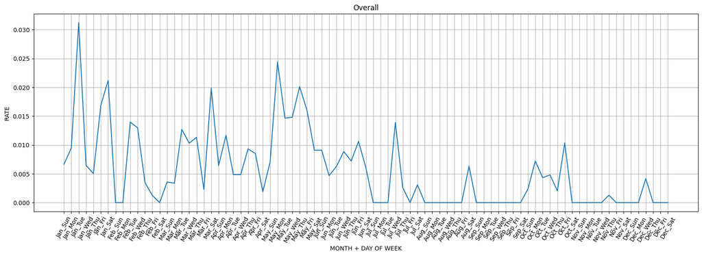

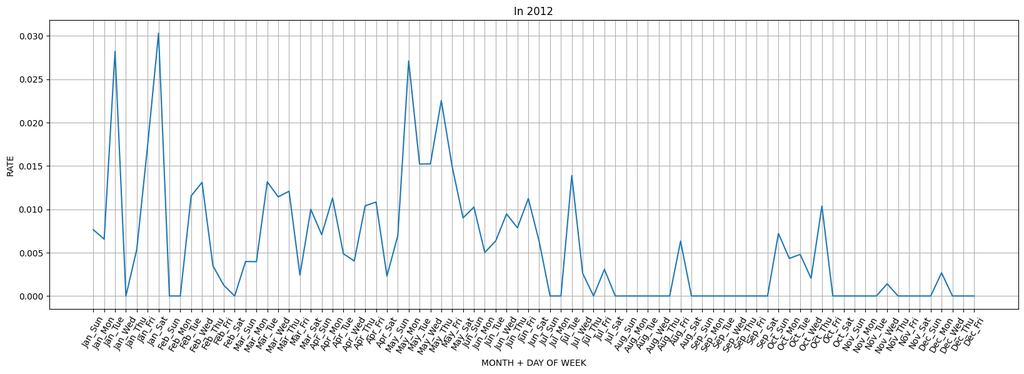

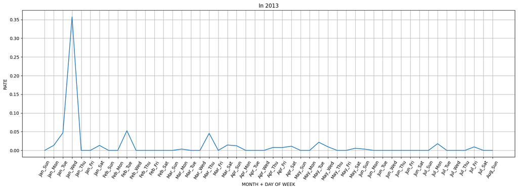

```python
display(Markdown("### REDEMPTION TREND DISTRIBUTION FOR BOTH YEARS 2012 & 2013."))

temp_df = final_df[['YEAR', 'MONTH', 'REDEMPTION_STATUS']]
temp_df['MONTH'] = temp_df['MONTH'].map({1:'Jan', 2:'Feb',3:'Mar', 4:'Apr', 5:'May', 6:'Jun',7:'Jul', 8:'Aug', 9:'Sep', 10:'Oct', 11:'Nov', 12:'Dec'})
temp_df = temp_df.groupby(['YEAR', 'MONTH']).agg({'REDEMPTION_STATUS':['sum', 'count']})
temp_df = pd.DataFrame((100 * temp_df[('REDEMPTION_STATUS',   'sum')]) / temp_df[('REDEMPTION_STATUS', 'count')])
display(temp_df.rename(columns = {0:'REDEMPTION RATE'}).T)

red_rate = final_df.groupby(['MONTH', 'DAYOFWEEK']).agg({'REDEMPTION_STATUS':['sum', 'count']}).reset_index()
red_rate_2012 = final_df[final_df['YEAR'] == 2012].groupby(['MONTH', 'DAYOFWEEK']).agg({'REDEMPTION_STATUS':['sum', 'count']}).reset_index()
red_rate_2013 = final_df[final_df['YEAR'] == 2013].groupby(['MONTH', 'DAYOFWEEK']).agg({'REDEMPTION_STATUS':['sum', 'count']}).reset_index()

red_rate['MONTH'] = red_rate['MONTH'].map({1:'Jan', 2:'Feb',3:'Mar', 4:'Apr', 5:'May', 6:'Jun',7:'Jul', 8:'Aug', 9:'Sep', 10:'Oct', 11:'Nov', 12:'Dec'})
red_rate['DAYOFWEEK'] = red_rate['DAYOFWEEK'].map({0:'Sun', 1:'Mon', 2:'Tue', 3:'Wed', 4:'Thu', 5:'Fri', 6:'Sat'})
plot_df = pd.DataFrame({
    'MONTH + DAY OF WEEK': red_rate[(            'MONTH',      '')].astype(str) +'_'+ red_rate[(        'DAYOFWEEK',      '')].astype(str) ,
    'RATE': ((red_rate[('REDEMPTION_STATUS',   'sum')]) / red_rate[('REDEMPTION_STATUS', 'count')])
})

plt.figure(figsize=(20,6))
fg =  sns.lineplot(y = plot_df['RATE'], x = plot_df['MONTH + DAY OF WEEK'])
fg.set_xticklabels(rotation=60, labels = plot_df['MONTH + DAY OF WEEK'])
plt.title("Overall")
plt.grid()
plt.show();

red_rate_2012['MONTH'] = red_rate_2012['MONTH'].map({1:'Jan', 2:'Feb',3:'Mar', 4:'Apr', 5:'May', 6:'Jun',7:'Jul', 8:'Aug', 9:'Sep', 10:'Oct', 11:'Nov', 12:'Dec'})
red_rate_2012['DAYOFWEEK'] = red_rate_2012['DAYOFWEEK'].map({0:'Sun', 1:'Mon', 2:'Tue', 3:'Wed', 4:'Thu', 5:'Fri', 6:'Sat'})
plot_df_2012 = pd.DataFrame({
    'MONTH + DAY OF WEEK': red_rate_2012[(            'MONTH',      '')].astype(str) +'_'+ red_rate[(        'DAYOFWEEK',      '')].astype(str) ,
    'RATE': ((red_rate_2012[('REDEMPTION_STATUS',   'sum')]) / red_rate_2012[('REDEMPTION_STATUS', 'count')])
})

plt.figure(figsize=(20,6))
fg =  sns.lineplot(y = plot_df_2012['RATE'], x = plot_df_2012['MONTH + DAY OF WEEK'])
fg.set_xticklabels(rotation=60, labels = plot_df['MONTH + DAY OF WEEK'])
plt.title("In 2012")
plt.grid()
plt.show();


red_rate_2013['MONTH'] = red_rate_2013['MONTH'].map({1:'Jan', 2:'Feb',3:'Mar', 4:'Apr', 5:'May', 6:'Jun',7:'Jul', 8:'Aug', 9:'Sep', 10:'Oct', 11:'Nov', 12:'Dec'})
red_rate_2013['DAYOFWEEK'] = red_rate_2013['DAYOFWEEK'].map({0:'Sun', 1:'Mon', 2:'Tue', 3:'Wed', 4:'Thu', 5:'Fri', 6:'Sat'})
plot_df_2013 = pd.DataFrame({
    'MONTH + DAY OF WEEK': red_rate_2013[(            'MONTH',      '')].astype(str) +'_'+ red_rate[(        'DAYOFWEEK',      '')].astype(str) ,
    'RATE': ((red_rate_2013[('REDEMPTION_STATUS',   'sum')]) / red_rate_2013[('REDEMPTION_STATUS', 'count')])
})


plt.figure(figsize=(20,6))
fg =  sns.lineplot(y = plot_df_2013['RATE'], x = plot_df_2013['MONTH + DAY OF WEEK'])
fg.set_xticklabels(rotation=60, labels = plot_df['MONTH + DAY OF WEEK'])
plt.title("In 2013")
plt.grid()
plt.show();
```

```python
display(Markdown("### Average Discount on each Category "))
display(final_df.groupby(['BRAND_TYPE','YEAR','CATEGORY'])[['TOTAL_DISCOUNT_MEAN']].mean())
```

Average Discount on each Category

| BRAND_TYPE | YEAR | CATEGORY | TOTAL_DISCOUNT_MEAN |
| --- | --- | --- | --- |
| Established | 2012 | Bakery | -1.678480 |
|  |  | Dairy, Juices & Snacks | -29.244557 |
|  |  | Grocery | -25.370476 |
|  |  | Meat | -22.910655 |
|  |  | Natural Products | -27.772973 |
|  |  | Packaged Meat | -34.892954 |
|  |  | Pharmaceutical | -31.492485 |
|  |  | Prepared Food | -26.996188 |
|  |  | Seafood | -51.561649 |
|  |  | Skin & Hair Care | -43.814916 |
|  | 2013 | Bakery | -1.678480 |
|  |  | Dairy, Juices & Snacks | -31.059718 |
|  |  | Grocery | -26.440052 |
|  |  | Meat | -24.882747 |
|  |  | Natural Products | -27.437436 |
|  |  | Packaged Meat | -36.434648 |
|  |  | Pharmaceutical | -31.722424 |
|  |  | Prepared Food | -30.963961 |
|  |  | Seafood | -51.699754 |
|  |  | Skin & Hair Care | -45.048890 |
| Local | 2012 | Bakery | -34.672652 |
|  |  | Dairy, Juices & Snacks | -6.680978 |
|  |  | Flowers & Plants | -75.623930 |
|  |  | Grocery | -19.787335 |
|  |  | Natural Products | -20.502986 |
|  |  | Packaged Meat | -46.342930 |
|  |  | Pharmaceutical | -236.586959 |
|  |  | Prepared Food | -27.735669 |
|  |  | Seafood | -131.241324 |
|  | 2013 | Bakery | -34.703926 |
|  |  | Dairy, Juices & Snacks | -6.680978 |
|  |  | Flowers & Plants | -94.750000 |
|  |  | Grocery | -19.152772 |
|  |  | Natural Products | -20.502986 |
|  |  | Packaged Meat | -50.179554 |
|  |  | Prepared Food | -28.036382 |
|  |  | Seafood | -29.701172 |

```python
display(Markdown("#### On CAMPAIGN TYPE X"))
display(final_df[final_df['CAMPAIGN_TYPE'] == 'X'].groupby(['BRAND_TYPE','YEAR','CATEGORY'])[['TOTAL_DISCOUNT_MEAN']].mean())
```

On CAMPAIGN TYPE X

| BRAND_TYPE | YEAR | CATEGORY | TOTAL_DISCOUNT_MEAN |
| --- | --- | --- | --- |
| Established | 2012 | Bakery | -1.678480 |
|  |  | Dairy, Juices & Snacks | -22.799813 |
|  |  | Grocery | -25.998030 |
|  |  | Meat | -22.910655 |
|  |  | Natural Products | -27.772973 |
|  |  | Packaged Meat | -28.766484 |
|  |  | Pharmaceutical | -31.309660 |
|  |  | Prepared Food | -26.996188 |
|  |  | Seafood | -51.561649 |
|  |  | Skin & Hair Care | -43.814916 |
|  | 2013 | Bakery | -1.678480 |
|  |  | Dairy, Juices & Snacks | -24.808822 |
|  |  | Grocery | -26.884250 |
|  |  | Meat | -24.882747 |
|  |  | Natural Products | -27.437436 |
|  |  | Packaged Meat | -30.049144 |
|  |  | Pharmaceutical | -30.479568 |
|  |  | Prepared Food | -30.963961 |
|  |  | Seafood | -51.699754 |
|  |  | Skin & Hair Care | -45.048890 |
| Local | 2012 | Bakery | -16.876376 |
|  |  | Flowers & Plants | -75.623930 |
|  |  | Grocery | -20.287853 |
|  |  | Natural Products | -20.502986 |
|  |  | Packaged Meat | -45.999595 |
|  |  | Prepared Food | -27.735669 |
|  |  | Seafood | -131.241324 |
|  | 2013 | Bakery | -16.934141 |
|  |  | Flowers & Plants | -94.750000 |
|  |  | Grocery | -19.620949 |
|  |  | Natural Products | -20.502986 |
|  |  | Packaged Meat | -50.179554 |
|  |  | Prepared Food | -28.036382 |
|  |  | Seafood | -29.701172 |

```python
display(Markdown("#### On CAMPAIGN TYPE Y"))
display(final_df[final_df['CAMPAIGN_TYPE'] == 'Y'].groupby(['BRAND_TYPE','YEAR','CATEGORY'])[['TOTAL_DISCOUNT_MEAN']].mean())
```

On CAMPAIGN TYPE Y

| BRAND_TYPE | YEAR | CATEGORY | TOTAL_DISCOUNT_MEAN |
| --- | --- | --- | --- |
| Established | 2012 | Dairy, Juices & Snacks | -33.170103 |
|  |  | Grocery | -23.828342 |
|  |  | Packaged Meat | -46.330189 |
|  |  | Pharmaceutical | -31.749065 |
|  | 2013 | Dairy, Juices & Snacks | -33.673730 |
|  |  | Grocery | -25.217546 |
|  |  | Packaged Meat | -47.016341 |
|  |  | Pharmaceutical | -33.182703 |
| Local | 2012 | Bakery | -83.570833 |
|  |  | Dairy, Juices & Snacks | -6.680978 |
|  |  | Grocery | -12.374219 |
|  |  | Packaged Meat | -77.672209 |
|  |  | Pharmaceutical | -236.586959 |
|  | 2013 | Bakery | -83.570833 |
|  |  | Dairy, Juices & Snacks | -6.680978 |
|  |  | Grocery | -11.736176 |

```python
display(Markdown("### CORRELATION"))
display(final_df.corr()[['REDEMPTION_STATUS']].T)
```

CORRELATION

|  | ID | CAMPAIGN_ID | COUPON_ID | CUSTOMER_ID | REDEMPTION_STATUS | BRAND | CUST_TRANS_BY_ITM_MAX_COUPON_DISCOUNT | CUST_TRANS_BY_ITM_MAX_COUPON_USED | CUST_TRANS_BY_ITM_MAX_NO_OF_CUSTOMERS | CUST_TRANS_BY_ITM_MAX_OTHER_DISCOUNT | CUST_TRANS_BY_ITM_MAX_QUANITY | CUST_TRANS_BY_ITM_MAX_SELLING_PRICE | CUST_TRANS_BY_ITM_MEAN_COUPON_DISCOUNT | CUST_TRANS_BY_ITM_MEAN_COUPON_USED | CUST_TRANS_BY_ITM_MEAN_NO_OF_CUSTOMERS | CUST_TRANS_BY_ITM_MEAN_OTHER_DISCOUNT | CUST_TRANS_BY_ITM_MEAN_QUANITY | CUST_TRANS_BY_ITM_MEAN_SELLING_PRICE | CUST_TRANS_BY_ITM_MIN_COUPON_DISCOUNT | CUST_TRANS_BY_ITM_MIN_COUPON_USED | CUST_TRANS_BY_ITM_MIN_NO_OF_CUSTOMERS | CUST_TRANS_BY_ITM_MIN_OTHER_DISCOUNT | CUST_TRANS_BY_ITM_MIN_QUANITY | CUST_TRANS_BY_ITM_MIN_SELLING_PRICE | CUST_TRANS_BY_ITM_SUM_COUPON_DISCOUNT | CUST_TRANS_BY_ITM_SUM_OTHER_DISCOUNT | CUST_TRANS_BY_ITM_SUM_QUANTITY | CUST_TRANS_BY_ITM_SUM_SELLING_PRICE | CUST_TRANS_BY_ITM_SUM_TRANS_COUNTS | … |
| --- | --- | --- | --- | --- | --- | --- | --- | --- | --- | --- | --- | --- | --- | --- | --- | --- | --- | --- | --- | --- | --- | --- | --- | --- | --- | --- | --- | --- | --- | --- |
| REDEMPTION_STATUS | -0.000328 | -0.007548 | 0.023334 | 0.01169 | 1.0 | -0.023362 | 0.004059 | 0.065849 | 0.081482 | 0.009949 | 0.053949 | 0.034192 | 0.000398 | 0.012985 | 0.03306 | -0.0081 | -0.001166 | -0.019453 | -0.046093 | -0.004143 | -0.016808 | -0.057017 | NaN | -0.03465 | -0.084245 | -0.079514 | 0.084605 | 0.078404 | 0.084627 | … |

## Causal Analysis

```
Causal analysis enables businesses to understand the causal relationships between various factors and the success or failure of their products or services. By analysing data and applying causal inference methods, businesses can identify which factors directly impact the outcome and differentiate them from mere correlations. This helps in making informed decisions regarding product development, marketing strategies, customer satisfaction, and overall business performance.
```

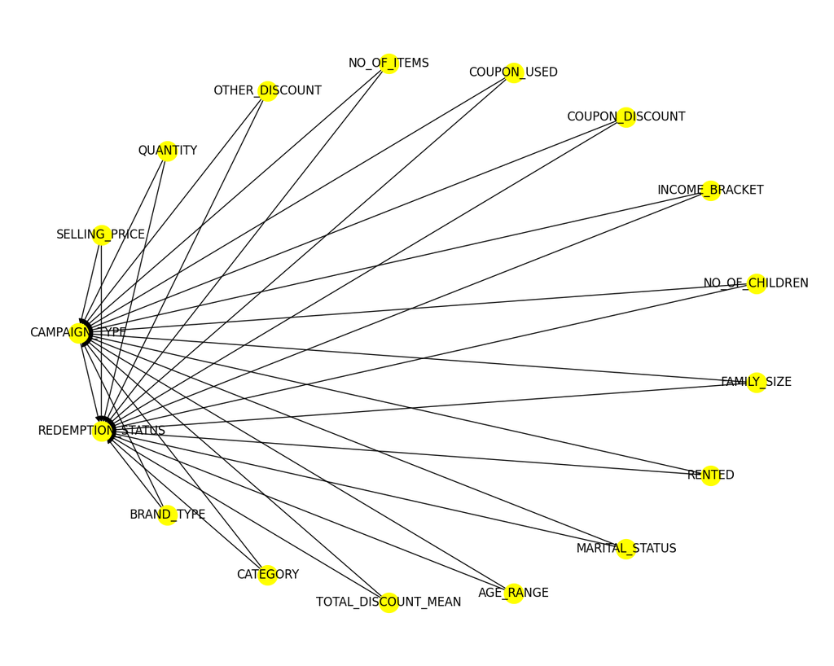

```python
import econml
from dowhy import CausalModel

treatment_feature = "CAMPAIGN_TYPE"
outcome_feature = "REDEMPTION_STATUS"
common_causes_features = ['BRAND_TYPE', 'CATEGORY', 'TOTAL_DISCOUNT_MEAN','AGE_RANGE',
                          'MARITAL_STATUS', 'RENTED', 'FAMILY_SIZE', 'NO_OF_CHILDREN',
                          'INCOME_BRACKET', 'COUPON_DISCOUNT', 'COUPON_USED',
                           'NO_OF_ITEMS', 'OTHER_DISCOUNT',
                          'QUANTITY', 'SELLING_PRICE']

causal_model = CausalModel(
        data=final_df,
        treatment=treatment_feature,
        outcome=outcome_feature,
        common_causes=common_causes_features
        )

# View model
causal_model.view_model(layout='dot', size=(15, 12))
```

```python
from causallib.preprocessing.confounder_selection import RecursiveConfounderElimination
from causallib.estimation import IPW, TMLE, XLearner, StratifiedStandardization, Standardization
from causallib.evaluation import evaluate
from sklearn.linear_model import LogisticRegression, LinearRegression
```

```python
## Helper functions

from toolz import curry

@curry
def elast(data, y, t):
        # line coeficient for the one variable linear regression
        return (np.sum((data[t] - data[t].mean())*(data[y] - data[y].mean())) /
                np.sum((data[t] - data[t].mean())**2))

def elast_by_band(df, pred, y, t, bands=10):
    return (df
            .assign(**{f"{pred}_band":pd.qcut(df[pred].drop_duplicates(), q=bands)}) # makes quantile partitions
            .groupby(f"{pred}_band")
            .apply(elast(y=y, t=t))) # estimate the elasticity on each partition

# def elast_by_band(df, pred, y, t, bands=10):
#     return (df
#             .assign(**{f"{pred}_band":pd.qcut(df[pred], q=bands)}) # makes quantile partitions
#             .groupby(f"{pred}_band")
#             .apply(elast(y=y, t=t))) # estimate the elasticity on each partition

def cumulative_elast_curve(dataset, prediction, y, t, min_periods=30, steps=100):
    size = dataset.shape[0]

    # orders the dataset by the `prediction` column
    ordered_df = dataset.sort_values(prediction, ascending=False).reset_index(drop=True)

    # create a sequence of row numbers that will define our Ks
    # The last item is the sequence is all the rows (the size of the dataset)
    n_rows = list(range(min_periods, size, size // steps)) + [size]

    # cumulative computes the elasticity. First for the top min_periods units.
    # then for the top (min_periods + step*1), then (min_periods + step*2) and so on
    return np.array([elast(ordered_df.head(rows), y, t) for rows in n_rows])


def cumulative_gain(dataset, prediction, y, t, min_periods=50, steps=1000):
    size = dataset.shape[0]
    ordered_df = dataset.sort_values(prediction, ascending=False).reset_index(drop=True)
    n_rows = list(range(min_periods, size, size // steps)) + [size]
    return np.array([elast(ordered_df.head(rows), y, t) * (rows/size) for rows in n_rows])

def elast_ci(df, y, t, z=1.96):
    n = df.shape[0]
    t_bar = df[t].mean()
    beta1 = elast(df, y, t)
    beta0 = df[y].mean() - beta1 * t_bar
    e = df[y] - (beta0 + beta1*df[t])
    se = np.sqrt(((1/(n-2))*np.sum(e**2))/np.sum((df[t]-t_bar)**2))
    return np.array([beta1 - z*se, beta1 + z*se])


def cumulative_elast_curve_ci(dataset, prediction, y, t, min_periods=30, steps=100):
    size = dataset.shape[0]
    ordered_df = dataset.sort_values(prediction, ascending=False).reset_index(drop=True)
    n_rows = list(range(min_periods, size, size // steps)) + [size]

    # just replacing a call to `elast` by a call to `elast_ci`
    return np.array([elast_ci(ordered_df.head(rows), y, t)  for rows in n_rows])
```

### New Segments

```python
final_df['SEGMENT_A'] = np.where((final_df['BRAND_TYPE'] == 'Established') & (final_df['CATEGORY'] == 'Grocery'), 1, 0)
final_df['SEGMENT_B'] = np.where(final_df['MARITAL_STATUS'] != 'Married', 0, 1)
final_df['SEGMENT_C'] = np.where((final_df['SEGMENT_A'] == 0) & (final_df['SEGMENT_B'] == 0),1,0)

def segment_dist_analysis(seg_name, df = final_df.copy()):
    temp_df = df.groupby([seg_name]).agg({'REDEMPTION_STATUS':['count', 'sum']}).reset_index()
    temp_df.columns = [seg_name, 'POP_DIST', 'REDEMPTION_RATE']
    temp_df['POP_DIST % '] = 100 * (temp_df['POP_DIST']) / temp_df['POP_DIST'].sum()
    temp_df['RATE % '] = 100 * (temp_df['REDEMPTION_RATE']) / temp_df['POP_DIST'].sum()
    return temp_df[[seg_name, 'POP_DIST % ', 'RATE % ']]

# display(segment_dist_analysis('SEGMENT_A'))
# display(segment_dist_analysis('SEGMENT_B'))
# display(segment_dist_analysis('SEGMENT_C'))

display(pd.DataFrame({
    'CAMPAIGN TYPE X': segment_dist_analysis('CAMPAIGN_TYPE').iloc[0:1,1:].values.ravel(),
    'SEGMENT_A': segment_dist_analysis('SEGMENT_A').iloc[1:,1:].values.ravel(),
    'SEGMENT_B': segment_dist_analysis('SEGMENT_B').iloc[1:,1:].values.ravel(),
    'SEGMENT_C': segment_dist_analysis('SEGMENT_C').iloc[1:,1:].values.ravel()
}, index = ['POP DIST %', 'REDEMPTION RATE %']).T)
```

|  | POP DIST % | REDEMPTION RATE % |
| --- | --- | --- |
| CAMPAIGN TYPE X | 73.605635 | 0.811545 |
| SEGMENT_A | 49.497888 | 0.761781 |
| SEGMENT_B | 91.599995 | 0.830686 |
| SEGMENT_C | 4.129184 | 0.015312 |

```python
## One Hot Encoding
import category_encoders as ce

df = final_df.drop(['ID', 'CAMPAIGN_ID', 'COUPON_ID', 'CUSTOMER_ID', 'START_DATE', 'END_DATE', 'BRAND',
                   'CUST_TRANS_BY_ITM_MEAN_COUPON_USED', 'CUST_TRANS_BY_ITM_MIN_COUPON_USED',
                    'CUST_TRANS_BY_ITM_SUM_COUPON_DISCOUNT', 'CUST_TRANS_BY_ITM_SUM_OTHER_DISCOUNT',
                    'TOTAL_DISCOUNT_SUM', ], axis = 1)

df[df.dtypes[df.dtypes == 'float'].index] = df[df.dtypes[df.dtypes == 'float'].index].apply(lambda x: np.round(x, 2))
df[['DAYOFWEEK', 'MONTH', 'DAY']] = df[[ 'DAYOFWEEK', 'MONTH', 'DAY']].astype(str)

categorical_cols = df.dtypes[df.dtypes == 'object'].index.to_list()
df_ohe = pd.concat([df, pd.get_dummies(df[categorical_cols])], axis = 1)
df_ohe.drop(categorical_cols, axis = 1, inplace = True)
df_ohe.columns = df_ohe.columns.str.replace(',','_').str.replace('-', '_').str.replace('&', '_').str.replace(' ', '_').str.strip()
df_ohe.columns.shape, len(set(df_ohe.columns.to_list()))
```

$\displaystyle \left( \left( 136,\right), \ 136\right)$

```python
## Train/Test Split

from sklearn.model_selection import train_test_split
from causallib.preprocessing.transformers import StandardScaler

seed = 1023
X = df_ohe.drop(['REDEMPTION_STATUS', 'YEAR'], axis=1)
Y = df_ohe['REDEMPTION_STATUS']

scaler = StandardScaler()
X_scaled = scaler.fit_transform(X)
X_train, X_test, y_train, y_test = train_test_split(X, Y, test_size=0.25, random_state=seed,stratify=Y)
```

### Campaign Type X

```python
%%time
## Variable Selection using Recurvise Feature Elimination
cols_to_drop = ['CAMPAIGN_TYPE_X','SEGMENT_A','SEGMENT_B','SEGMENT_C', 'CAMPAIGN_TYPE_Y']

learner = LinearRegression()
rc_eslim = RecursiveConfounderElimination(learner, n_features_to_select = 60, step=1)
rc_eslim.fit(
    X = X_train.drop(cols_to_drop, axis=1),
    a = X_train['CAMPAIGN_TYPE_X'],
    y = y_train
)

campaign_type_x_cols = rc_eslim.get_feature_names_out(
    input_features=X_train.drop(cols_to_drop, axis=1).columns.to_list()
)
print('SELECTED FEATURES:', len(campaign_type_x_cols))
```

```
SELECTED FEATURES: 60
CPU times: user 3min 18s, sys: 1min 20s, total: 4min 39s
Wall time: 36.7 s
```

```python
## Model Simulator to find best model

import xgboost as xgb
import lightgbm as lgb
from tqdm import tqdm
import scikitplot as skplt
from sklearn.ensemble import RandomForestRegressor
from sklearn.model_selection import GridSearchCV
from causallib.estimation import StratifiedStandardization, Standardization
from causallib.estimation import RLearner

# treatment_model = LogisticRegression(max_iter=2000)
treatment_model = xgb.XGBClassifier() #lgb.LGBMClassifier(**final_params_best)

outcome_model = GridSearchCV(
    RandomForestRegressor(),
    {'max_depth':[2,4,6]}, n_jobs=-1, cv=3
)


models = {
    'R-Learner': RLearner(outcome_model=outcome_model,
                          treatment_model=treatment_model,
                          effect_model=LinearRegression(fit_intercept=False),
                          effect_covariates=list(), # homogeneous effect
                          n_splits=2,
                          refit=False),
    'S-Learner': Standardization(outcome_model),
    'T-Learner': StratifiedStandardization(outcome_model),
}

def simulation_runner(n_repetitions, X , a, y):
    """
    Generating results of estimated effect for all of the models
    """
    results = list()
    for seed in tqdm(range(n_repetitions)):
        for model_name, model in models.items():
            model.fit(X, a, y)
            # estimate Average Treatment Effect
            pop = model.estimate_population_outcome(
                X, a
            )
            effect = model.estimate_effect(
                pop.loc[1], pop.loc[0]
            )['diff']
            results.append((effect, model_name))
    df_results=pd.DataFrame(results,columns=['effect','method'])
    return df_results

def plot_model_results(ind_outcomes_train, ind_outcomes_test, treatment_var, y_test,band):
    plt.figure(figsize=(12,4))
    plt.subplot(1,2,1)
    val_df_train = pd.merge(X_train, ind_outcomes_train, left_index=True, right_index=True)
    val_df_train = pd.merge(val_df_train, y_train, left_index=True, right_index=True)
    band_train = elast_by_band(df = val_df_train, pred = 1, y = 'REDEMPTION_STATUS', t = treatment_var, bands=band)

    plt.title('Elasticity by band in train data')
    plt.bar(band_train.index.astype(str).to_list(), band_train.values.tolist())
    plt.xticks(rotation=90)

    plt.subplot(1,2,2)
    val_df_test = pd.merge(X_test,ind_outcomes_test, left_index=True, right_index=True)
    val_df_test = pd.merge(val_df_test, y_test, left_index=True, right_index=True)
    band_test = elast_by_band(df = val_df_test, pred = 1, y = 'REDEMPTION_STATUS', t = treatment_var, bands=band)

    plt.title('Elasticity by band in test data')
    plt.bar(band_test.index.astype(str).to_list(), band_test.values.tolist())
    plt.xticks(rotation=90)
    plt.show()

    ##################################################################################

    plt.figure(figsize=(12,4))
#     plt.subplot(1,2,1)
    cumu_elast_train = cumulative_elast_curve(dataset=val_df_train, prediction= 1, y = 'REDEMPTION_STATUS', t = treatment_var, min_periods=30, steps=200)
    cumu_elast_test = cumulative_elast_curve(dataset=val_df_test, prediction= 1, y = 'REDEMPTION_STATUS', t = treatment_var, min_periods=30, steps=200)

    x = np.array(range(len(cumu_elast_train)))
    x_test = np.array(range(len(cumu_elast_test)))
    plt.plot(x/x.max(), cumu_elast_train, label='Cumulative Elasticity Curve on train data')
    plt.plot(x_test/x_test.max(), cumu_elast_test, label='Cumulative Elasticity Curve on test data')

    # plt.hlines(elast(val_df_2012, 1, "REDEMPTION_STATUS"), 0, 1, linestyles="--", color="black", label="Avg. Elast.")
    plt.hlines(0, 0, 1, linestyles="--", color="black", label="Avg. Elast.")
    plt.xlabel("--")
    plt.ylabel("Cumulative Elasticity")
    plt.title("Cumulative Elasticity Curve")
    plt.legend()
    plt.grid()

#     plt.subplot(1,2,2)
#     cumu_gain_train = cumulative_gain(dataset=val_df_train, prediction= 1, y = 'REDEMPTION_STATUS', t = treatment_var, min_periods=30, steps=200)
#     cumu_gain_test = cumulative_gain(dataset=val_df_test, prediction= 1, y = 'REDEMPTION_STATUS', t = treatment_var, min_periods=30, steps=200)
#     x = np.array(range(len(cumu_gain_train)))
#     x_test = np.array(range(len(cumu_gain_test)))
#     plt.plot(x/x.max(), cumu_gain_train, label='Cumulative Gain 2012')
#     plt.plot(x_test/x_test.max(), cumu_gain_test, label='Cumulative Gain 2013')
#     plt.plot([0, 1], [0, elast(val_df_train, 1, "REDEMPTION_STATUS")], linestyle=":",
#              label="Random Model",
#              color="black")
#     plt.xlabel("% of Redemption Status")
#     plt.ylabel("Cumulative Gain")
    plt.figure(figsize=(15,4))
    grid = plt.GridSpec(1, 2, wspace=0.3, hspace=0.4)
    for i in range(2):

        col, row = i%2,i//2
        ax = plt.subplot(grid[row,col])
        if i == 0: skplt.metrics.plot_cumulative_gain(y_test, ind_outcomes_test, ax = ax)
        else: skplt.metrics.plot_lift_curve(y_test, ind_outcomes_test, ax = ax);


def model_result_eval(model, X, a, y):
    test_df = model.estimate_individual_outcome(X, a, predict_proba=True)
    test_df['target_class'] = y
    test_df['lift_score'] = test_df[1]/(test_df[0] + test_df[1])
    return test_df

def get_Gain_Lift(df, is_decile=True):
    if is_decile:
        dec_name = 'Decile'
        dec_val = 10
    else:
        dec_name = 'Percentile'
        dec_val = 100

    df[dec_name] = pd.qcut(df[1], dec_val, labels=pd.qcut(df[1], dec_val, duplicates='drop').unique(), duplicates='drop')
    res = pd.crosstab(df[dec_name], df['target_class'])[1].reset_index().rename(columns = {1: 'Number of Responses'})
    lg = df[dec_name].value_counts(sort = False).reset_index().rename(columns = {dec_name: 'Number of Cases', 'index': dec_name})
    lg = pd.merge(lg, res, on = dec_name).sort_values(by = dec_name, ascending = False).reset_index(drop = True)
    lg['Cumulative Responses'] = lg['Number of Responses'].cumsum()
    lg['% of Events'] = np.round(((lg['Number of Responses']/lg['Number of Responses'].sum())*dec_val),2)
    lg['Gain'] = lg['% of Events'].cumsum()
    lg['Lift'] = np.round((lg['Gain']/(pd.Series(range(1,dec_val+1))*10)),2)
    return lg

def optimalCutoff(target, predicted):
    from sklearn.metrics import roc_curve
    fpr, tpr, threshold = roc_curve(target, predicted)
    i = np.arange(len(tpr))
    roc = pd.DataFrame({'tf' : pd.Series(tpr-(1-fpr), index=i), 'threshold' : pd.Series(threshold, index=i)})
    roc_t = roc.iloc[(roc.tf-0).abs().argsort()[:1]]
    return list(roc_t['threshold'])
```

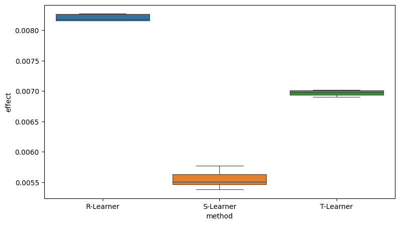

```python
campaign_type_x_results = simulation_runner(
    n_repetitions = 5,
    X = X_train.drop(cols_to_drop, axis=1)[campaign_type_x_cols],
    a = X_train['CAMPAIGN_TYPE_X'],
    y = y_train
)

fig, ax = plt.subplots(ncols=1, figsize=(9,5))
sns.boxplot(data=campaign_type_x_results.loc[campaign_type_x_results.method != 'True_ATE',:],
            y='effect',
            x='method',
            linewidth=0.8,
            ax=ax);
```

```python
%%time
campaign_type_x_model = RLearner(
    outcome_model=RandomForestRegressor(max_depth=6),
    treatment_model=treatment_model,
    effect_model=LinearRegression(fit_intercept=False),
    effect_covariates=list(), # homogeneous effect
    n_splits=2,
    refit=False
)

campaign_type_x_model.fit(
    X = X_train[campaign_type_x_cols],
    a = X_train['CAMPAIGN_TYPE_X'],
    y = y_train
)

outcomes = campaign_type_x_model.estimate_population_outcome(
    X = X_test[campaign_type_x_cols],
    a = X_test['CAMPAIGN_TYPE_X'],
    y = y_test
)
effects = campaign_type_x_model.estimate_effect(outcomes[1], outcomes[0], effect_types=["diff", "ratio"])
print("ATE:", effects[0])
```

```
ATE: 0.008184773703830951
CPU times: user 38.4 s, sys: 35.8 ms, total: 38.4 s
Wall time: 8.73 s
```

```python
ind_outcomes_train = campaign_type_x_model.estimate_individual_outcome(
    X = X_train[campaign_type_x_cols],
    a = X_train['CAMPAIGN_TYPE_X'],
)

ind_outcomes_test = campaign_type_x_model.estimate_individual_outcome(
    X = X_test[campaign_type_x_cols],
    a = X_test['CAMPAIGN_TYPE_X'],
)
```

```
ATE: 0.0082
None
```

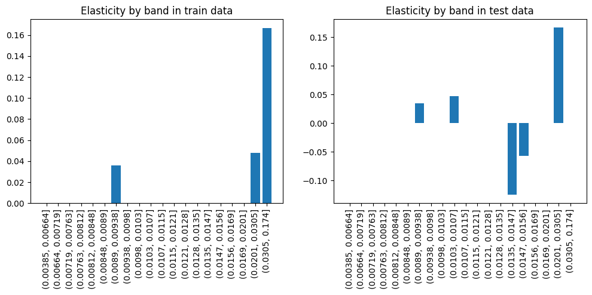

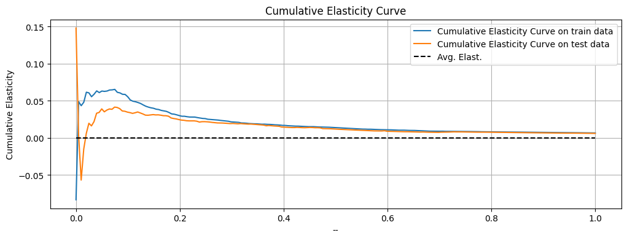

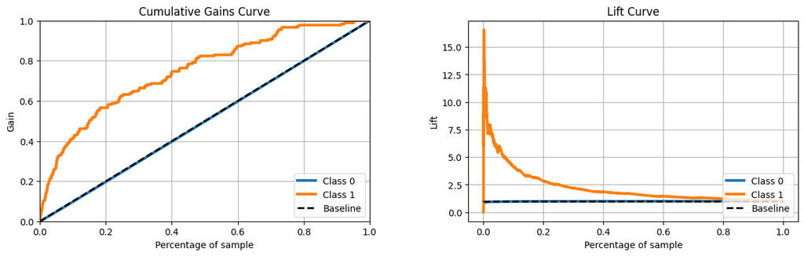

```python
print(print("ATE:", round(effects[0], 4)))
plot_model_results(ind_outcomes_train, ind_outcomes_test, 'CAMPAIGN_TYPE_X', y_test, 20)
```

Percentile/Decile wise Distribution

Train/Test Sample

|  | Decile | Number of Cases | Number of Responses | Cumulative Responses | % of Events | Gain | Lift |
| --- | --- | --- | --- | --- | --- | --- | --- |
| 0 | (0.017, 0.174] | 6109 | 28 | 28 | 0.51 | 0.51 | 0.05 |
| 1 | (0.0141, 0.017] | 5630 | 37 | 65 | 0.68 | 1.19 | 0.06 |
| 2 | (0.0118, 0.0141] | 4812 | 18 | 83 | 0.33 | 1.52 | 0.05 |
| 3 | (0.0104, 0.0118] | 5496 | 12 | 95 | 0.22 | 1.74 | 0.04 |
| 4 | (0.00898, 0.0104] | 5680 | 63 | 158 | 1.15 | 2.89 | 0.06 |
| 5 | (0.00765, 0.00898] | 5866 | 290 | 448 | 5.30 | 8.19 | 0.14 |
| 6 | (0.00642, 0.00765] | 6200 | 10 | 458 | 0.18 | 8.37 | 0.12 |
| 7 | (0.00582, 0.00642] | 6056 | 42 | 500 | 0.77 | 9.14 | 0.11 |
| 8 | (0.00551, 0.00582] | 6758 | 18 | 518 | 0.33 | 9.47 | 0.11 |
| 9 | (0.00385, 0.00551] | 6169 | 29 | 547 | 0.53 | 10.00 | 0.10 |

Validation Sample

|  | Decile | Number of Cases | Number of Responses | Cumulative Responses | % of Events | Gain | Lift |
| --- | --- | --- | --- | --- | --- | --- | --- |
| 0 | (0.0169, 0.174] | 1651 | 12 | 12 | 0.66 | 0.66 | 0.07 |
| 1 | (0.0141, 0.0169] | 1704 | 3 | 15 | 0.16 | 0.82 | 0.04 |
| 2 | (0.0117, 0.0141] | 2098 | 4 | 19 | 0.22 | 1.04 | 0.03 |
| 3 | (0.0104, 0.0117] | 2326 | 2 | 21 | 0.11 | 1.15 | 0.03 |
| 4 | (0.0089, 0.0104] | 1759 | 12 | 33 | 0.66 | 1.81 | 0.04 |
| 5 | (0.00765, 0.0089] | 1969 | 16 | 49 | 0.88 | 2.69 | 0.04 |
| 6 | (0.00642, 0.00765] | 2019 | 11 | 60 | 0.60 | 3.29 | 0.05 |
| 7 | (0.00582, 0.00642] | 1953 | 75 | 135 | 4.12 | 7.41 | 0.09 |
| 8 | (0.00551, 0.00582] | 1953 | 28 | 163 | 1.54 | 8.95 | 0.10 |
| 9 | (0.00385, 0.00551] | 2161 | 19 | 182 | 1.04 | 9.99 | 0.10 |

Classification Report and Confusion Matrix

```
              precision    recall  f1-score   support

           0       1.00      0.72      0.83     19411
           1       0.02      0.65      0.04       182

    accuracy                           0.72     19593
   macro avg       0.51      0.68      0.44     19593
weighted avg       0.99      0.72      0.83     19593
```

```
None
```

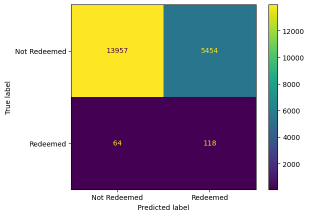

Average Impact of Campaign Type X

```
Average impact:  0.01
```

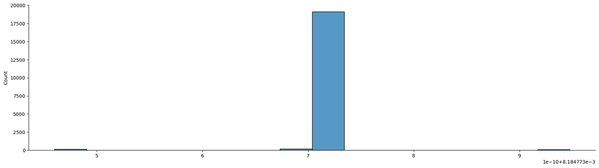

```python
train_ls_df = model_result_eval(model = campaign_type_x_model, X = X_train[campaign_type_x_cols],  a = X_train['CAMPAIGN_TYPE_X'], y = y_train)
test_ls_df = model_result_eval(model = campaign_type_x_model, X = X_test[campaign_type_x_cols], a = X_test['CAMPAIGN_TYPE_X'], y = y_test)

display(Markdown("### Percentile/Decile wise Distribution"))

display(Markdown("#### Train/Test Sample"))
display(get_Gain_Lift(train_ls_df.copy(), is_decile=True).iloc[:20,:], )

display(Markdown("#### Validation Sample"))
display(get_Gain_Lift(test_ls_df.copy(), is_decile=True).iloc[:20,:])


display(Markdown("### Classification Report and Confusion Matrix"))
test_ls_df['predicted'] = (test_ls_df[1] > optimalCutoff(train_ls_df['target_class'],train_ls_df[1])[0]).astype(int)
display(print(classification_report(test_ls_df['target_class'], test_ls_df['predicted'])))

ConfusionMatrixDisplay(
    confusion_matrix= confusion_matrix(test_ls_df['target_class'], test_ls_df['predicted']),
    display_labels=['Not Redeemed','Redeemed']
).plot()
plt.show();

display(Markdown("### Average Impact of Campaign Type X"))
print('Average impact: ', np.round((test_ls_df[1] - test_ls_df[0]).mean(), 2))
sns.displot((test_ls_df[1] - test_ls_df[0]), aspect=3.5);
```

### Segment A

```python
%%time

cols_to_drop = ['CAMPAIGN_TYPE_X','SEGMENT_A','SEGMENT_B','SEGMENT_C', 'CAMPAIGN_TYPE_Y']

learner = LinearRegression()
rc_eslim = RecursiveConfounderElimination(learner, n_features_to_select = 60, step=1)
rc_eslim.fit(
    X = X_train.drop(cols_to_drop, axis=1),
    a = X_train['SEGMENT_A'],
    y = y_train
)

selected_cols_seg_a = rc_eslim.get_feature_names_out(
    input_features=X_train.drop(cols_to_drop, axis=1).columns.to_list()
)

print('SELECTED FEATURES:', len(selected_cols_seg_a))
```

```
SELECTED FEATURES: 60
CPU times: user 3min 7s, sys: 1min 12s, total: 4min 19s
Wall time: 33.6 s
```

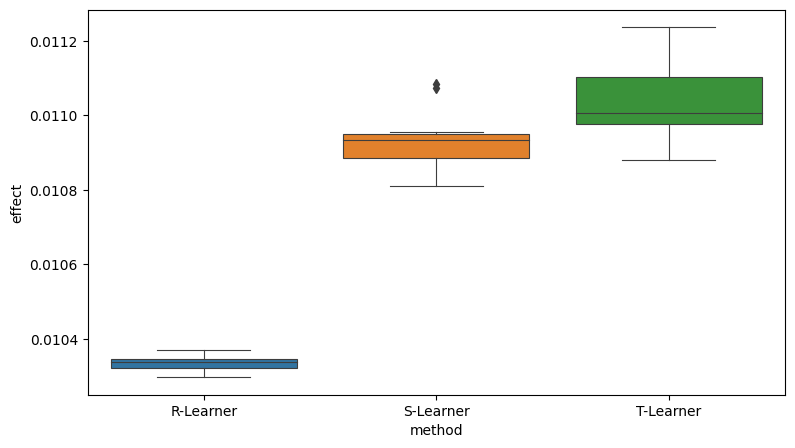

```python
seg_a_results = simulation_runner(
    n_repetitions = 10,
    X = X_train.drop(cols_to_drop, axis=1)[selected_cols_seg_a],
    a = X_train['SEGMENT_A'],
    y = y_train
)

fig, ax = plt.subplots(ncols=1, figsize=(9,5))
sns.boxplot(data=seg_a_results.loc[seg_a_results.method != 'True_ATE',:],
            y='effect',
            x='method',
            linewidth=0.8,
            ax=ax);
```

```python
from sklearn.linear_model import Ridge, Lasso, ElasticNet, SGDRegressor
```

```python
%%time
# seg_a_model = RLearner(
#     outcome_model=RandomForestRegressor(max_depth=6),
#     treatment_model=treatment_model,
#     effect_model=LinearRegression(fit_intercept=False),
#     effect_covariates=list(), # homogeneous effect
#     n_splits=2,
#     refit=False
# )

seg_a_model = StratifiedStandardization(RandomForestRegressor(max_depth=4))
# seg_a_model = Standardization(learner= xgb.XGBRFRegressor())

seg_a_model.fit(
    X = X_train[selected_cols_seg_a],
    a = X_train['SEGMENT_A'],
    y = y_train
)

outcomes = seg_a_model.estimate_population_outcome(
    X = X_test[selected_cols_seg_a],
    a = X_test['SEGMENT_A'],
    y = y_test
)
effects = seg_a_model.estimate_effect(outcomes[1], outcomes[0], effect_types=["diff", "ratio"])
print("ATE:", effects[0])
```

```
ATE: 0.010767338944465198
CPU times: user 3.46 s, sys: 703 µs, total: 3.46 s
Wall time: 3.46 s
```

```python
ind_outcomes_train = seg_a_model.estimate_individual_outcome(
    X = X_train[selected_cols_seg_a],
    a = X_train['SEGMENT_A'],
)

ind_outcomes_test = seg_a_model.estimate_individual_outcome(
    X = X_test[selected_cols_seg_a],
    a = X_test['SEGMENT_A'],
)
```

```
ATE: 0.0108
None
```

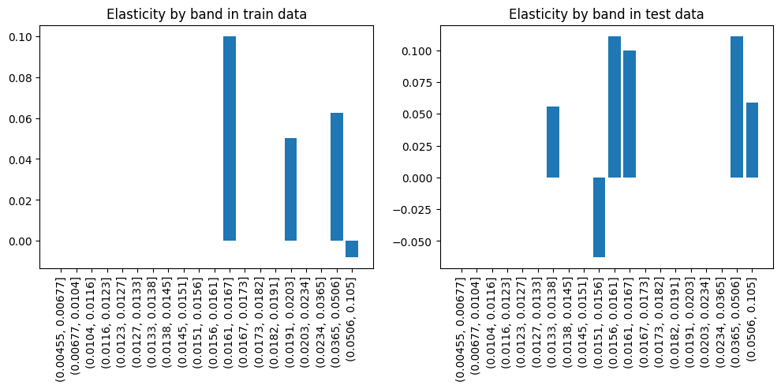

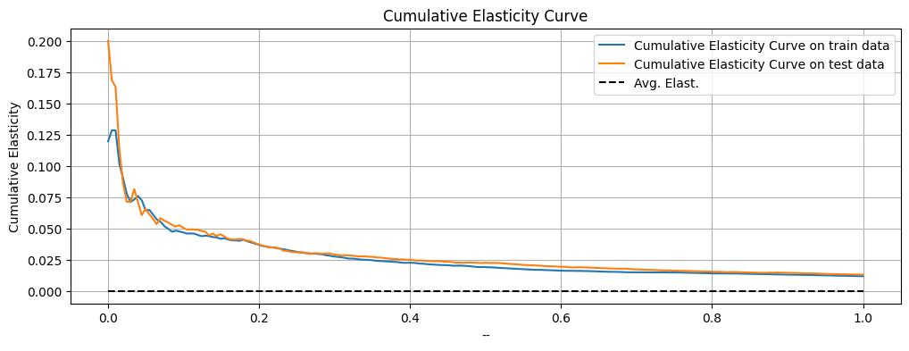

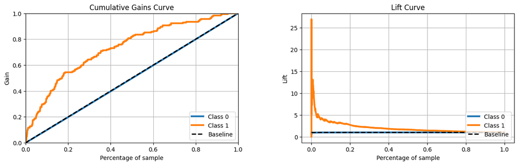

```python
print(print("ATE:", round(effects[0], 4)))
plot_model_results(ind_outcomes_train, ind_outcomes_test, 'SEGMENT_A', y_test, 20)
```

Percentile/Decile wise Distribution

Train/Test Sample

|  | Decile | Number of Cases | Number of Responses | Cumulative Responses | % of Events | Gain | Lift |
| --- | --- | --- | --- | --- | --- | --- | --- |
| 0 | (0.024, 0.105] | 5767 | 47 | 47 | 0.86 | 0.86 | 0.09 |
| 1 | (0.018, 0.024] | 5877 | 114 | 161 | 2.08 | 2.94 | 0.15 |
| 2 | (0.0159, 0.018] | 6636 | 33 | 194 | 0.60 | 3.54 | 0.12 |
| 3 | (0.014, 0.0159] | 5885 | 46 | 240 | 0.84 | 4.38 | 0.11 |
| 4 | (0.0124, 0.014] | 5850 | 11 | 251 | 0.20 | 4.58 | 0.09 |
| 5 | (0.0103, 0.0124] | 5856 | 209 | 460 | 3.82 | 8.40 | 0.14 |
| 6 | (0.00809, 0.0103] | 5152 | 25 | 485 | 0.46 | 8.86 | 0.13 |
| 7 | (0.00702, 0.00809] | 6236 | 10 | 495 | 0.18 | 9.04 | 0.11 |
| 8 | (0.00641, 0.00702] | 5985 | 38 | 533 | 0.69 | 9.73 | 0.11 |
| 9 | (0.00455, 0.00641] | 5532 | 14 | 547 | 0.26 | 9.99 | 0.10 |

Validation Sample

|  | Decile | Number of Cases | Number of Responses | Cumulative Responses | % of Events | Gain | Lift |
| --- | --- | --- | --- | --- | --- | --- | --- |
| 0 | (0.0233, 0.105] | 1992 | 2 | 2 | 0.11 | 0.11 | 0.01 |
| 1 | (0.018, 0.0233] | 1886 | 9 | 11 | 0.49 | 0.60 | 0.03 |
| 2 | (0.0159, 0.018] | 1956 | 37 | 48 | 2.03 | 2.63 | 0.09 |
| 3 | (0.014, 0.0159] | 2035 | 3 | 51 | 0.16 | 2.79 | 0.07 |
| 4 | (0.0124, 0.014] | 1959 | 16 | 67 | 0.88 | 3.67 | 0.07 |
| 5 | (0.01, 0.0124] | 1956 | 18 | 85 | 0.99 | 4.66 | 0.08 |
| 6 | (0.00799, 0.01] | 1959 | 7 | 92 | 0.38 | 5.04 | 0.07 |
| 7 | (0.00693, 0.00799] | 1957 | 62 | 154 | 3.41 | 8.45 | 0.11 |
| 8 | (0.00641, 0.00693] | 1958 | 16 | 170 | 0.88 | 9.33 | 0.10 |
| 9 | (0.00455, 0.00641] | 1935 | 12 | 182 | 0.66 | 9.99 | 0.10 |

Classification Report and Confusion Matrix

```
              precision    recall  f1-score   support

           0       1.00      0.68      0.81     19411
           1       0.02      0.66      0.04       182

    accuracy                           0.68     19593
   macro avg       0.51      0.67      0.42     19593
weighted avg       0.99      0.68      0.80     19593
```

```
None
```

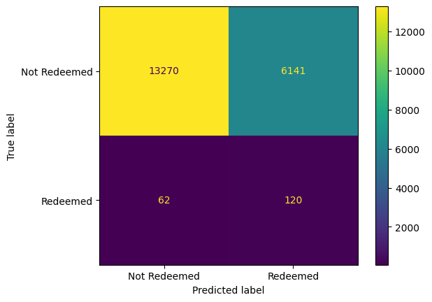

Average Impact of Segment A

```
Average impact:  0.01
```

```python
train_ls_df = model_result_eval(model = seg_a_model, X = X_train[selected_cols_seg_a],  a = X_train['SEGMENT_A'], y = y_train)
test_ls_df = model_result_eval(model = seg_a_model, X = X_test[selected_cols_seg_a], a = X_test['SEGMENT_A'], y = y_test)

display(Markdown("### Percentile/Decile wise Distribution"))

display(Markdown("#### Train/Test Sample"))
display(get_Gain_Lift(train_ls_df.copy(), is_decile=True).iloc[:20,:], )

display(Markdown("#### Validation Sample"))
display(get_Gain_Lift(test_ls_df.copy(), is_decile=True).iloc[:20,:])
# sns.barplot(y = [train_ls_df['lift_score'].mean(), test_ls_df['lift_score'].mean()], x =['Train', 'Test']);

display(Markdown("### Classification Report and Confusion Matrix"))
test_ls_df['predicted'] = (test_ls_df[1] > optimalCutoff(train_ls_df['target_class'],train_ls_df[1])[0]).astype(int)
display(print(classification_report(test_ls_df['target_class'], test_ls_df['predicted'])))

ConfusionMatrixDisplay(
    confusion_matrix= confusion_matrix(test_ls_df['target_class'], test_ls_df['predicted']),
    display_labels=['Not Redeemed','Redeemed']
).plot()
plt.show();

display(Markdown("### Average Impact of Segment A"))
print('Average impact: ', np.round((test_ls_df[1] - test_ls_df[0]).mean(), 2))
# sns.displot((test_ls_df[1] - test_ls_df[0]), aspect=3.5);
```

### Segment B

```python
%%time

cols_to_drop = ['CAMPAIGN_TYPE_X','SEGMENT_A','SEGMENT_B','SEGMENT_C', 'CAMPAIGN_TYPE_Y']

learner = LinearRegression()
rc_eslim = RecursiveConfounderElimination(learner, n_features_to_select = 60, step=1)
rc_eslim.fit(
    X = X_train.drop(cols_to_drop, axis=1),
    a = X_train['SEGMENT_B'],
    y = y_train
)

selected_cols_seg_b = rc_eslim.get_feature_names_out(
    input_features=X_train.drop(cols_to_drop, axis=1).columns.to_list()
)
print('SELECTED FEATURES:', len(selected_cols_seg_b))
```

```
SELECTED FEATURES: 60
CPU times: user 2min 57s, sys: 1min 9s, total: 4min 6s
Wall time: 31.9 s
```

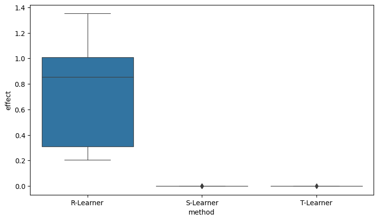

```python
seg_b_results = simulation_runner(
    n_repetitions = 5,
    X = X_train.drop(cols_to_drop, axis=1)[selected_cols_seg_b],
    a = X_train['SEGMENT_B'],
    y = y_train
)

fig, ax = plt.subplots(ncols=1, figsize=(9,5))
sns.boxplot(data=seg_b_results.loc[seg_b_results.method != 'True_ATE',:],
            y='effect',
            x='method',
            linewidth=0.8,
            ax=ax);
```

```python
%%time
seg_b_model = RLearner(
    outcome_model=RandomForestRegressor(max_depth=2),
    treatment_model=treatment_model,
    effect_model=LinearRegression(fit_intercept=False),
    effect_covariates=list(), # homogeneous effect
    n_splits=2,
    refit=False
)

# seg_b_model =Standardization(learner=Ridge(random_state=seed), predict_proba=True)
seg_b_model.fit(
    X = X_train[selected_cols_seg_b],
    a = X_train['SEGMENT_B'],
    y = y_train
)

outcomes = seg_b_model.estimate_population_outcome(
    X = X_test[selected_cols_seg_b],
    a = X_test['SEGMENT_B'],
    y = y_test
)
effects = seg_b_model.estimate_effect(outcomes[1], outcomes[0], effect_types=["diff", "ratio"])
print("ATE:", effects[0])
```

```
ATE: 1.76950005524898
CPU times: user 12.8 s, sys: 59 ms, total: 12.8 s
Wall time: 3.34 s
```

```python
ind_outcomes_train = seg_b_model.estimate_individual_outcome(
    X = X_train[selected_cols_seg_b],
    a = X_train['SEGMENT_B'],
)

ind_outcomes_test = seg_b_model.estimate_individual_outcome(
    X = X_test[selected_cols_seg_b],
    a = X_test['SEGMENT_B'],
)
```

```
ATE: 1.7695
None
```

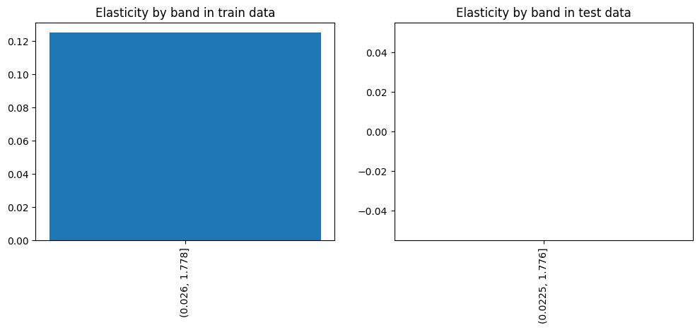

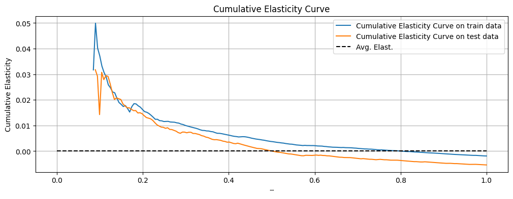

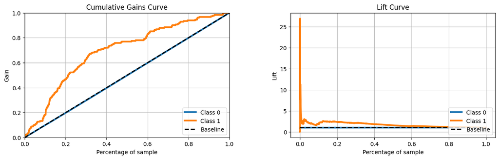

```python
print(print("ATE:", round(effects[0], 4)))
plot_model_results(ind_outcomes_train, ind_outcomes_test,'SEGMENT_B', y_test, 20)
```

Percentile/Decile wise Distribution

Train/Test Sample

|  | Decile | Number of Cases | Number of Responses | Cumulative Responses | % of Events | Gain | Lift |
| --- | --- | --- | --- | --- | --- | --- | --- |
| 0 | (0.02, 1.7941] | 9864 | 76 | 76 | 1.39 | 1.39 | 0.14 |
| 1 | (0.01591, 0.02] | 5715 | 81 | 157 | 1.48 | 2.87 | 0.14 |
| 2 | (0.01084, 0.01591] | 5400 | 139 | 296 | 2.54 | 5.41 | 0.18 |
| 3 | (0.01075, 0.01084] | 5772 | 95 | 391 | 1.74 | 7.15 | 0.18 |
| 4 | (0.007592, 0.01075] | 7301 | 60 | 451 | 1.10 | 8.25 | 0.16 |
| 5 | (0.006631, 0.007592] | 2590 | 25 | 476 | 0.46 | 8.71 | 0.15 |
| 6 | (0.005766, 0.006631] | 6164 | 10 | 486 | 0.18 | 8.89 | 0.13 |
| 7 | (0.005712, 0.005766] | 7946 | 25 | 511 | 0.46 | 9.35 | 0.12 |
| 8 | (0.004625, 0.005712] | 3587 | 17 | 528 | 0.31 | 9.66 | 0.11 |
| 9 | (0.004314999999999999, 0.004625] | 4437 | 19 | 547 | 0.35 | 10.01 | 0.10 |

Validation Sample

|  | Decile | Number of Cases | Number of Responses | Cumulative Responses | % of Events | Gain | Lift |
| --- | --- | --- | --- | --- | --- | --- | --- |
| 0 | (0.02016, 1.7947] | 1331 | 2 | 2 | 0.11 | 0.11 | 0.01 |
| 1 | (0.01591, 0.02016] | 2761 | 8 | 10 | 0.44 | 0.55 | 0.03 |
| 2 | (0.01084, 0.01591] | 1980 | 6 | 16 | 0.33 | 0.88 | 0.03 |
| 3 | (0.01075, 0.01084] | 1214 | 7 | 23 | 0.38 | 1.26 | 0.03 |
| 4 | (0.007577, 0.01075] | 1871 | 32 | 55 | 1.76 | 3.02 | 0.06 |
| 5 | (0.006631, 0.007577] | 1914 | 52 | 107 | 2.86 | 5.88 | 0.10 |
| 6 | (0.005748, 0.006631] | 3221 | 16 | 123 | 0.88 | 6.76 | 0.10 |
| 7 | (0.005712, 0.005748] | 1943 | 27 | 150 | 1.48 | 8.24 | 0.10 |
| 8 | (0.004602, 0.005712] | 2515 | 19 | 169 | 1.04 | 9.28 | 0.10 |
| 9 | (0.004314999999999999, 0.004602] | 843 | 13 | 182 | 0.71 | 9.99 | 0.10 |

Classification Report and Confusion Matrix

```
              precision    recall  f1-score   support

           0       0.99      0.71      0.83     19411
           1       0.02      0.61      0.04       182

    accuracy                           0.71     19593
   macro avg       0.51      0.66      0.43     19593
weighted avg       0.99      0.71      0.82     19593
```

```
None
```

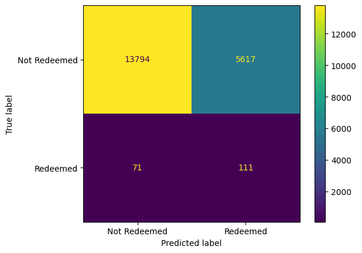

Average Impact of Segment B

```
Average impact:  1.77
```

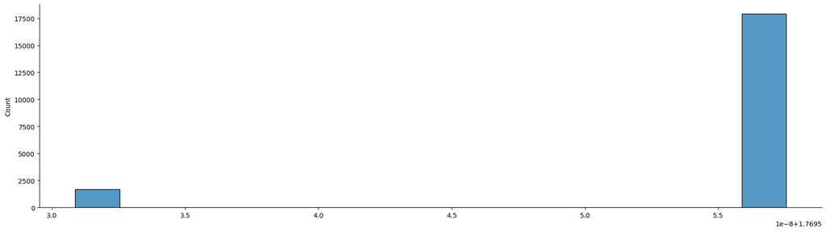

```python
train_ls_df = model_result_eval(model = seg_b_model, X = X_train[selected_cols_seg_b],  a = X_train['SEGMENT_B'], y = y_train)
test_ls_df = model_result_eval(model = seg_b_model, X = X_test[selected_cols_seg_b], a = X_test['SEGMENT_B'], y = y_test)

display(Markdown("### Percentile/Decile wise Distribution"))

display(Markdown("#### Train/Test Sample"))
display(get_Gain_Lift(train_ls_df.copy(), is_decile=True).iloc[:20,:], )

display(Markdown("#### Validation Sample"))
display(get_Gain_Lift(test_ls_df.copy(), is_decile=True).iloc[:20,:])

display(Markdown("### Classification Report and Confusion Matrix"))
test_ls_df['predicted'] = (test_ls_df[1] > optimalCutoff(train_ls_df['target_class'],train_ls_df[1])[0]).astype(int)
display(print(classification_report(test_ls_df['target_class'], test_ls_df['predicted'])))

ConfusionMatrixDisplay(
    confusion_matrix= confusion_matrix(test_ls_df['target_class'], test_ls_df['predicted']),
    display_labels=['Not Redeemed','Redeemed']
).plot()
plt.show();

display(Markdown("### Average Impact of Segment B"))
print('Average impact: ', np.round((test_ls_df[1] - test_ls_df[0]).mean(), 2))
sns.displot((test_ls_df[1] - test_ls_df[0]), aspect=3.5);
```